# Aproximación a la calidad de datos

```python
%matplotlib inline
%reload_ext autoreload
%autoreload
SEED = 1234
import warnings
warnings.simplefilter(action='ignore', category=FutureWarning)
from IPython.display import display, HTML
from time import time
import numpy as np
import numpy.ma as ma
np.set_printoptions(precision=4)
np.random.seed(SEED)
import pandas as  pd
#pd.options.display.max_rows
#pd.set_option('display.max_colwidth', -1)
#pd.set_option('display.max_rows', 5)
pd.set_option('display.max_columns', 44)
pd.set_option('precision', 3)
pd.options.mode.chained_assignment = None
import matplotlib.pyplot as plt
%matplotlib inline
plt.rcParams.update({'figure.figsize':(7,5), 'figure.dpi':100})


from scipy.cluster.hierarchy import dendrogram, linkage
```

```python
presupuesto = pd.read_csv("../presupuesto-ejecutado-2018-segundo-trimestre.csv")
```

# Analisis Descriptivo

Aclaración:

Tablas: Las tablas de frecuencia estan ordenadas desde el elemento más frecuente al menos frecuente. Por lo que la MODA es el primer elemento de la tabla.

Análisis sobre las variables Categóricas:

```python
df_categoricas = presupuesto.select_dtypes(include=['object'])
#df_categoricas.info()
```

```python
df_datos = df_categoricas[["Car_desc"]].groupby(["Car_desc"])["Car_desc"].count().reset_index(name='Cantidad')
df_datos["Porcentaje"] = df_datos["Cantidad"]/df_datos["Cantidad"].sum() * 100
df_datos = df_datos.sort_values(by="Cantidad", ascending = False)
display(df_datos)
```

|  | Car_desc | Cantidad | Porcentaje |
| --- | --- | --- | --- |
| 0 | Administracion Central | 40450 | 82.888 |
| 1 | Organismos Descentralizados | 8351 | 17.112 |

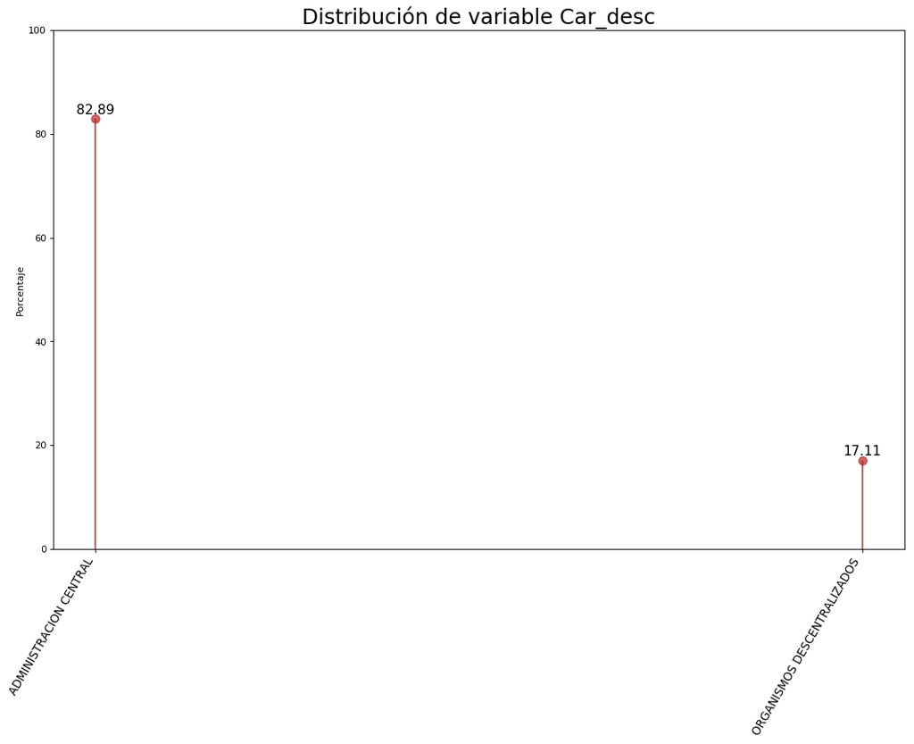

```python
df_datos = df_datos.rename(columns={'Car_desc':'Etiquetas'})
fig, ax = plt.subplots(figsize=(16,10), dpi= 80)
ax.vlines(x=df_datos.index, ymin=0, ymax=df_datos.Porcentaje, color='firebrick', alpha=0.7, linewidth=2)
ax.scatter(x=df_datos.index, y=df_datos.Porcentaje, s=75, color='firebrick', alpha=0.7)
ax.set_title('Distribución de variable Car_desc', fontdict={'size':22})
ax.set_ylabel('Porcentaje')
ax.set_xticks(df_datos.index)
ax.set_xticklabels(df_datos.Etiquetas.str.upper(), rotation=60, fontdict={'horizontalalignment': 'right', 'size':12})
ax.set_ylim(0, 100)
for row in df_datos.itertuples():
    ax.text(row.Index, row.Porcentaje+.5, s=round(row.Porcentaje, 2), horizontalalignment= 'center', verticalalignment='bottom', fontsize=14)

plt.show()
```

Análisis sobre la variable Jur_desc

```python
df_datos = df_categoricas[["Jur_desc"]].groupby(["Jur_desc"])["Jur_desc"].count().reset_index(name='Cantidad')
df_datos["Porcentaje"] = df_datos["Cantidad"]/df_datos["Cantidad"].sum() * 100
df_datos = df_datos.sort_values(by="Cantidad", ascending = False)
display(df_datos)
```

|  | Jur_desc | Cantidad | Porcentaje |
| --- | --- | --- | --- |
| 11 | Ministerio De Educacion | 7636 | 15.647 |
| 15 | Ministerio De Salud | 6015 | 12.326 |
| 8 | Ministerio De Ambiente Y Espacio Publico | 5157 | 10.567 |
| 3 | Jefatura De Gabinete De Ministros | 4727 | 9.686 |
| 14 | Ministerio De Justicia Y Seguridad | 4502 | 9.225 |
| 4 | Jefatura De Gobierno | 4424 | 9.065 |
| 10 | Ministerio De Desarrollo Urbano Y Transporte | 2906 | 5.955 |
| 13 | Ministerio De Hacienda | 2793 | 5.723 |
| 6 | Min.Hàbitat Y Des. Humano | 2726 | 5.586 |
| 9 | Ministerio De Cultura | 2370 | 4.856 |
| 7 | Min.Modern.Innovacion Y Tecnologia | 1791 | 3.670 |
| 12 | Ministerio De Gobierno | 1363 | 2.793 |
| 16 | Ministerio Publico | 644 | 1.320 |
| 18 | Procuracion General De La Ciudad | 373 | 0.764 |
| 1 | Consejo De La Magistratura | 346 | 0.709 |
| 21 | Tribunal Superior De Justicia | 318 | 0.652 |
| 2 | Defensoria Del Pueblo | 194 | 0.398 |
| 17 | Obligaciones A Cargo Del Tesoro | 184 | 0.377 |
| 20 | Sindicatura General De La Ciudad De Buenos Aires | 179 | 0.367 |
| 5 | Legislatura De La Ciudad De Buenos Aires | 75 | 0.154 |
| 0 | Auditoria General De La Ciudad De Buenos Aires | 63 | 0.129 |
| 19 | Servicio De La Deuda Publica | 15 | 0.031 |

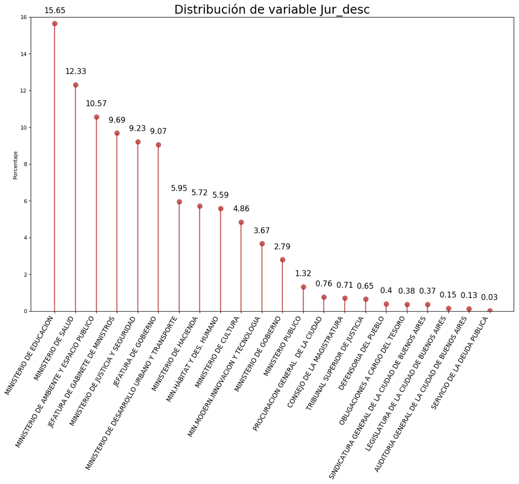

```python
df_datos = df_datos.rename(columns={'Jur_desc':'Etiquetas'}).head(22).reset_index()
fig, ax = plt.subplots(figsize=(16,10), dpi= 80)
ax.vlines(x=df_datos.index, ymin=0, ymax=df_datos.Porcentaje, color='firebrick', alpha=0.7, linewidth=2)
ax.scatter(x=df_datos.index, y=df_datos.Porcentaje, s=75, color='firebrick', alpha=0.7)
ax.set_title('Distribución de variable Jur_desc', fontdict={'size':22})
ax.set_ylabel('Porcentaje')
ax.set_xticks(df_datos.index)
ax.set_xticklabels(df_datos.Etiquetas.str.upper(), rotation=60, fontdict={'horizontalalignment': 'right', 'size':12})
ax.set_ylim(0, 16)
for row in df_datos.itertuples():
    ax.text(row.Index, row.Porcentaje+.5, s=round(row.Porcentaje, 2), horizontalalignment= 'center', verticalalignment='bottom', fontsize=14)

plt.show()
```

Análisis sobre la variable Sjur_desc

```python
df_datos = df_categoricas[["Sjur_desc"]].groupby(["Sjur_desc"])["Sjur_desc"].count().reset_index(name='Cantidad')
df_datos["Porcentaje"] = df_datos["Cantidad"]/df_datos["Cantidad"].sum() * 100
df_datos = df_datos.sort_values(by="Cantidad", ascending = False)
display(df_datos)
```

|  | Sjur_desc | Cantidad | Porcentaje |
| --- | --- | --- | --- |
| 11 | Ministerio De Educacion | 7636 | 15.647 |
| 15 | Ministerio De Salud | 6015 | 12.326 |
| 8 | Ministerio De Ambiente Y Espacio Publico | 4861 | 9.961 |
| 3 | Jefatura De Gabinete De Ministros | 4727 | 9.686 |
| 10 | Ministerio De Desarrollo Urbano Y Transporte | 2906 | 5.955 |
| 13 | Ministerio De Hacienda | 2793 | 5.723 |
| 6 | Min.Hàbitat Y Des. Humano | 2726 | 5.586 |
| 14 | Ministerio De Justicia Y Seguridad | 2622 | 5.373 |
| 9 | Ministerio De Cultura | 2370 | 4.856 |
| 19 | Plan De Seguridad Publica | 1880 | 3.852 |
| 7 | Min.Modern.Innovacion Y Tecnologia | 1791 | 3.670 |
| 12 | Ministerio De Gobierno | 1363 | 2.793 |
| 28 | Vicejefatura De Gobierno | 1348 | 2.762 |
| 21 | Sec.Gral. Y Realaciones Internacionales | 935 | 1.916 |
| 18 | Organismos Descentralizados | 813 | 1.666 |
| 16 | Ministerio Publico | 644 | 1.320 |
| 22 | Secretaria De Medios | 450 | 0.922 |
| 23 | Secretaria Legal Y Tecnica | 441 | 0.904 |
| 4 | Jefatura De Gobierno | 437 | 0.895 |
| 20 | Procuracion General De La Ciudad | 373 | 0.764 |
| 1 | Consejo De La Magistratura | 346 | 0.709 |
| 26 | Tribunal Superior De Justicia | 318 | 0.652 |
| 27 | Vias Peatonales | 296 | 0.607 |
| 2 | Defensoria Del Pueblo | 194 | 0.398 |
| 17 | Obligaciones A Cargo Del Tesoro | 184 | 0.377 |
| 25 | Sindicatura General De La Ciudad De Buenos Aires | 179 | 0.367 |
| 5 | Legislatura De La Ciudad De Buenos Aires | 75 | 0.154 |
| 0 | Auditoria General De La Ciudad De Buenos Aires | 63 | 0.129 |
| 24 | Servicio De La Deuda Publica | 15 | 0.031 |

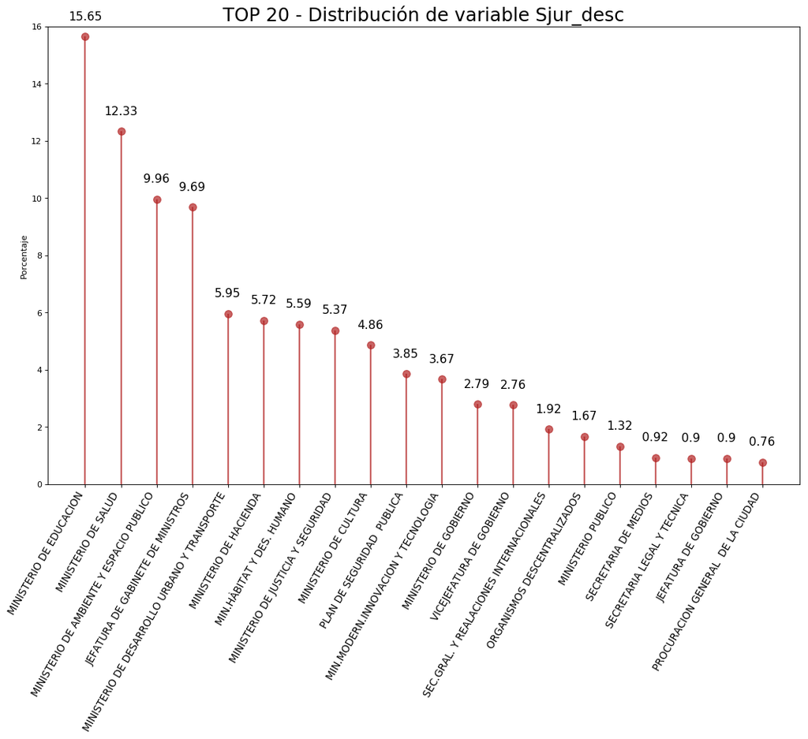

```python
df_datos = df_datos.rename(columns={'Sjur_desc':'Etiquetas'}).head(20).reset_index()
fig, ax = plt.subplots(figsize=(16,10), dpi= 80)
ax.vlines(x=df_datos.index, ymin=0, ymax=df_datos.Porcentaje, color='firebrick', alpha=0.7, linewidth=2)
ax.scatter(x=df_datos.index, y=df_datos.Porcentaje, s=75, color='firebrick', alpha=0.7)
ax.set_title('TOP 20 - Distribución de variable Sjur_desc', fontdict={'size':22})
ax.set_ylabel('Porcentaje')
ax.set_xticks(df_datos.index)
ax.set_xticklabels(df_datos.Etiquetas.str.upper(), rotation=60, fontdict={'horizontalalignment': 'right', 'size':12})
ax.set_ylim(0, 16)
for row in df_datos.itertuples():
    ax.text(row.Index, row.Porcentaje+.5, s=round(row.Porcentaje, 2), horizontalalignment= 'center', verticalalignment='bottom', fontsize=14)

plt.show()
```

Análisis sobre la variable Ent_desc

```python
df_datos = presupuesto[["Ent_desc"]].groupby(["Ent_desc"])["Ent_desc"].count().reset_index(name='Cantidad')
df_datos["Porcentaje"] = df_datos["Cantidad"]/df_datos["Cantidad"].sum() * 100
df_datos = df_datos.sort_values(by="Cantidad", ascending = False)
display(df_datos)
```

|  | Ent_desc | Cantidad | Porcentaje |
| --- | --- | --- | --- |
| 40 | Ministerio De Educacion | 7636 | 15.647 |
| 44 | Ministerio De Salud | 6015 | 12.326 |
| 37 | Ministerio De Ambiente Y Espacio Publico | 3254 | 6.668 |
| 39 | Ministerio De Desarrollo Urbano Y Transporte | 2906 | 5.955 |
| 35 | Min.Hàbitat Y Des. Humano | 2726 | 5.586 |
| 38 | Ministerio De Cultura | 2082 | 4.266 |
| 32 | Jefatura De Gabinete De Ministros | 1958 | 4.012 |
| 43 | Ministerio De Justicia Y Seguridad | 1836 | 3.762 |
| 47 | Plan De Seguridad Publica | 1795 | 3.678 |
| 42 | Ministerio De Hacienda | 1739 | 3.563 |
| 36 | Min.Modern.Innovacion Y Tecnologia | 1540 | 3.156 |
| 41 | Ministerio De Gobierno | 1362 | 2.791 |
| 58 | Vicejefatura De Gobierno | 1348 | 2.762 |
| 1 | Agencia Ambiental | 1290 | 2.643 |
| 0 | Admin. Gubernamental De Ingresos Publicos | 1054 | 2.160 |
| 3 | Agencia Gubernamental De Control | 760 | 1.557 |
| 50 | Sec.Gral. Y Realaciones Internacionales | 674 | 1.381 |
| 45 | Ministerio Publico | 644 | 1.320 |
| 51 | Secretaria De Medios | 450 | 0.922 |
| 4 | Agencia Sistemas De Informacion | 448 | 0.918 |
| 52 | Secretaria Legal Y Tecnica | 441 | 0.904 |
| 33 | Jefatura De Gobierno | 437 | 0.895 |
| 22 | Consejo De Las Niñas Niños Y Adolescentes | 431 | 0.883 |
| 29 | Ente Regulador De Servicios Publicos | 382 | 0.783 |
| 48 | Procuracion General De La Ciudad | 373 | 0.764 |
| 30 | Instituto Para La Vivienda | 365 | 0.748 |
| 21 | Consejo De La Magistratura | 346 | 0.709 |
| 56 | Tribunal Superior De Justicia | 318 | 0.652 |
| 57 | Vias Peatonales | 296 | 0.607 |
| 55 | Teatro Colon | 288 | 0.590 |
| 2 | Agencia De Turismo | 261 | 0.535 |
| 26 | Ente De Turismo | 250 | 0.512 |
| 25 | Defensoria Del Pueblo | 194 | 0.398 |
| 46 | Obligaciones A Cargo Del Tesoro | 184 | 0.377 |
| 28 | Ente Mantenimiento Urbano Integral | 180 | 0.369 |
| 54 | Sindicatura General De La Ciudad De Buenos Aires | 179 | 0.367 |
| 19 | Comuna 8 | 170 | 0.348 |
| 8 | Comuna 11 | 166 | 0.340 |
| 11 | Comuna 14 | 165 | 0.338 |
| 18 | Comuna 7 | 160 | 0.328 |
| 10 | Comuna 13 | 147 | 0.301 |
| 27 | Ente De Higiene Urbana | 137 | 0.281 |
| 17 | Comuna 6 | 137 | 0.281 |
| 20 | Comuna 9 | 137 | 0.281 |
| 16 | Comuna 5 | 121 | 0.248 |
| 7 | Comuna 10 | 117 | 0.240 |
| 15 | Comuna 4 | 114 | 0.234 |
| 13 | Comuna 2 | 112 | 0.230 |
| 9 | Comuna 12 | 106 | 0.217 |
| 6 | Comuna 1 | 104 | 0.213 |
| 12 | Comuna 15 | 102 | 0.209 |
| 14 | Comuna 3 | 98 | 0.201 |
| 31 | Instituto Superior De Seguridad Publica | 85 | 0.174 |
| 34 | Legislatura De La Ciudad De Buenos Aires | 75 | 0.154 |
| 5 | Auditoria General De La Ciudad De Buenos Aires | 63 | 0.129 |
| 49 | Registro Publico Comercio Y Contralor Personas... | 26 | 0.053 |
| 53 | Servicio De La Deuda Publica | 15 | 0.031 |
| 24 | Consejo Economico Y Social De La Caba | 1 | 0.002 |
| 23 | Consejo Economico Y Social De La C.A.B.A | 1 | 0.002 |

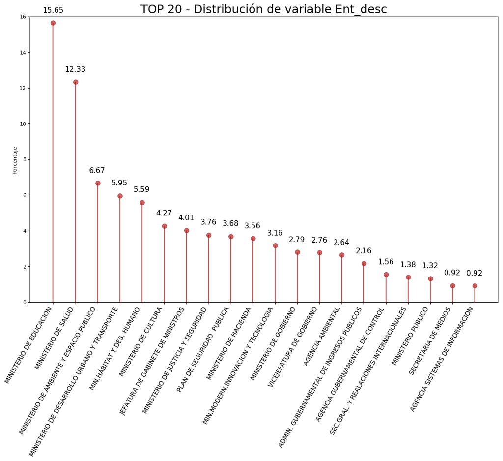

```python
df_datos = df_datos.rename(columns={'Ent_desc':'Etiquetas'}).head(20).reset_index()
fig, ax = plt.subplots(figsize=(16,10), dpi= 80)
ax.vlines(x=df_datos.index, ymin=0, ymax=df_datos.Porcentaje, color='firebrick', alpha=0.7, linewidth=2)
ax.scatter(x=df_datos.index, y=df_datos.Porcentaje, s=75, color='firebrick', alpha=0.7)
ax.set_title('TOP 20 - Distribución de variable Ent_desc', fontdict={'size':22})
ax.set_ylabel('Porcentaje')
ax.set_xticks(df_datos.index)
ax.set_xticklabels(df_datos.Etiquetas.str.upper(), rotation=60, fontdict={'horizontalalignment': 'right', 'size':12})
ax.set_ylim(0, 16)
for row in df_datos.itertuples():
    ax.text(row.Index, row.Porcentaje+.5, s=round(row.Porcentaje, 2), horizontalalignment= 'center', verticalalignment='bottom', fontsize=14)

plt.show()
```

Análisis sobre la variable Og_desc

```python
df_datos = df_categoricas[["Og_desc"]].groupby(["Og_desc"])["Og_desc"].count().reset_index(name='Cantidad')
df_datos["Porcentaje"] = df_datos["Cantidad"]/df_datos["Cantidad"].sum() * 100
df_datos = df_datos.sort_values(by="Cantidad", ascending = False)
display(df_datos)
```

|  | Og_desc | Cantidad | Porcentaje |
| --- | --- | --- | --- |
| 40 | Ministerio De Educacion | 7636 | 15.647 |
| 44 | Ministerio De Salud | 6015 | 12.326 |
| 37 | Ministerio De Ambiente Y Espacio Publico | 3254 | 6.668 |
| 39 | Ministerio De Desarrollo Urbano Y Transporte | 2906 | 5.955 |
| 35 | Min.Hàbitat Y Des. Humano | 2726 | 5.586 |
| 38 | Ministerio De Cultura | 2082 | 4.266 |
| 32 | Jefatura De Gabinete De Ministros | 1958 | 4.012 |
| 43 | Ministerio De Justicia Y Seguridad | 1836 | 3.762 |
| 47 | Plan De Seguridad Publica | 1795 | 3.678 |
| 42 | Ministerio De Hacienda | 1739 | 3.563 |
| 36 | Min.Modern.Innovacion Y Tecnologia | 1540 | 3.156 |
| 41 | Ministerio De Gobierno | 1362 | 2.791 |
| 58 | Vicejefatura De Gobierno | 1348 | 2.762 |
| 1 | Agencia Ambiental | 1290 | 2.643 |
| 0 | Admin. Gubernamental De Ingresos Publicos | 1054 | 2.160 |
| 3 | Agencia Gubernamental De Control | 760 | 1.557 |
| 50 | Sec.Gral. Y Realaciones Internacionales | 674 | 1.381 |
| 45 | Ministerio Publico | 644 | 1.320 |
| 51 | Secretaria De Medios | 450 | 0.922 |
| 4 | Agencia Sistemas De Informacion | 448 | 0.918 |
| 52 | Secretaria Legal Y Tecnica | 441 | 0.904 |
| 33 | Jefatura De Gobierno | 437 | 0.895 |
| 22 | Consejo De Las Niñas Niños Y Adolescentes | 431 | 0.883 |
| 29 | Ente Regulador De Servicios Publicos | 382 | 0.783 |
| 48 | Procuracion General De La Ciudad | 373 | 0.764 |
| 30 | Instituto Para La Vivienda | 365 | 0.748 |
| 21 | Consejo De La Magistratura | 346 | 0.709 |
| 56 | Tribunal Superior De Justicia | 318 | 0.652 |
| 57 | Vias Peatonales | 296 | 0.607 |
| 55 | Teatro Colon | 288 | 0.590 |
| 2 | Agencia De Turismo | 261 | 0.535 |
| 27 | Ente De Turismo | 250 | 0.512 |
| 25 | Defensoria Del Pueblo | 194 | 0.398 |
| 46 | Obligaciones A Cargo Del Tesoro | 184 | 0.377 |
| 28 | Ente Mantenimiento Urbano Integral | 180 | 0.369 |
| 54 | Sindicatura General De La Ciudad De Buenos Aires | 179 | 0.367 |
| 19 | Comuna 8 | 170 | 0.348 |
| 8 | Comuna 11 | 166 | 0.340 |
| 11 | Comuna 14 | 165 | 0.338 |
| 18 | Comuna 7 | 160 | 0.328 |
| 10 | Comuna 13 | 147 | 0.301 |
| 26 | Ente De Higiene Urbana | 137 | 0.281 |
| 17 | Comuna 6 | 137 | 0.281 |
| 20 | Comuna 9 | 137 | 0.281 |
| 16 | Comuna 5 | 121 | 0.248 |
| 7 | Comuna 10 | 117 | 0.240 |
| 15 | Comuna 4 | 114 | 0.234 |
| 13 | Comuna 2 | 112 | 0.230 |
| 9 | Comuna 12 | 106 | 0.217 |
| 6 | Comuna 1 | 104 | 0.213 |
| 12 | Comuna 15 | 102 | 0.209 |
| 14 | Comuna 3 | 98 | 0.201 |
| 31 | Instituto Superior De Seguridad Publica | 85 | 0.174 |
| 34 | Legislatura De La Ciudad De Buenos Aires | 75 | 0.154 |
| 5 | Auditoria General De La Ciudad De Buenos Aires | 63 | 0.129 |
| 49 | Registro Publico Comercio Y Contralor Personas... | 26 | 0.053 |
| 53 | Servicio De La Deuda Publica | 15 | 0.031 |
| 24 | Consejo Economico Y Social De La Caba | 1 | 0.002 |
| 23 | Consejo Economico Y Social De La C.A.B.A | 1 | 0.002 |

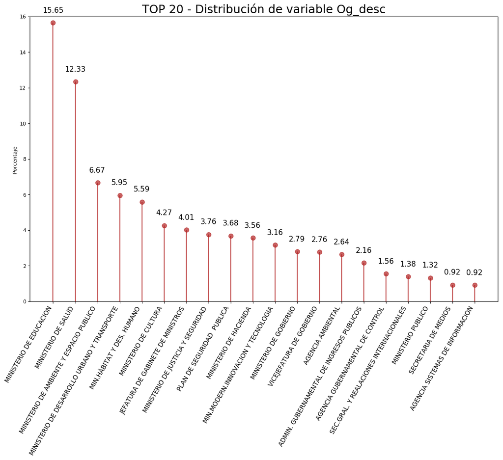

```python
df_datos = df_datos.rename(columns={'Og_desc':'Etiquetas'}).head(20).reset_index()
fig, ax = plt.subplots(figsize=(16,10), dpi= 80)
ax.vlines(x=df_datos.index, ymin=0, ymax=df_datos.Porcentaje, color='firebrick', alpha=0.7, linewidth=2)
ax.scatter(x=df_datos.index, y=df_datos.Porcentaje, s=75, color='firebrick', alpha=0.7)
# Title, Label, Ticks and Ylim
ax.set_title('TOP 20 - Distribución de variable Og_desc', fontdict={'size':22})
ax.set_ylabel('Porcentaje')
ax.set_xticks(df_datos.index)
ax.set_xticklabels(df_datos.Etiquetas.str.upper(), rotation=60, fontdict={'horizontalalignment': 'right', 'size':12})
ax.set_ylim(0, 16)
# Annotate
for row in df_datos.itertuples():
    ax.text(row.Index, row.Porcentaje+.5, s=round(row.Porcentaje, 2), horizontalalignment= 'center', verticalalignment='bottom', fontsize=14)

plt.show()
```

Análisis sobre la variable UE_desc

```python
df_datos = df_categoricas[["UE_desc"]].groupby(["UE_desc"])["UE_desc"].count().reset_index(name='Cantidad')
df_datos["Porcentaje"] = df_datos["Cantidad"]/df_datos["Cantidad"].sum() * 100
df_datos = df_datos.sort_values(by="Cantidad", ascending = False)
display(df_datos)
```

|  | UE_desc | Cantidad | Porcentaje |
| --- | --- | --- | --- |
| 68 | Dir. Gral De Educacion De Gestion Estatal | 3825 | 7.838 |
| 2 | Agencia Ambiental | 833 | 1.707 |
| 270 | Ss. Carrera Docente Y Formacion Tecnico Profes... | 623 | 1.277 |
| 0 | Administ.Gubernamental De Ingresos Publicos | 616 | 1.262 |
| 291 | Subsecretaria De Coordinacion Pedagogica Y Equ... | 559 | 1.145 |
| 94 | Dir.Gral. Fiscalizaciòn Del Espacio Publico | 545 | 1.117 |
| 183 | Dirección General De Educación Superior | 517 | 1.059 |
| 195 | Ente De Turismo | 511 | 1.047 |
| 143 | Direccion General De Espacios Verdes | 495 | 1.014 |
| 85 | Dir.Gral Administracion De Infracciones | 474 | 0.971 |
| 119 | Dir.Gral.Patrimonio Museos Y Casco Historico | 449 | 0.920 |
| 248 | Ministerio Público Fiscal | 445 | 0.912 |
| 144 | Direccion General De Estadisticas Y Censos | 438 | 0.898 |
| 34 | Consejo De Los Derechos De Las Niñas, Niños Y ... | 431 | 0.883 |
| 251 | Policia De La Ciudad | 424 | 0.869 |
| 265 | Secretaria Integracion Social Para Personas Ma... | 403 | 0.826 |
| 196 | Ente Regulador De Los Servicios Publicos | 382 | 0.783 |
| 252 | Procuracion General De La Ciudad | 373 | 0.764 |
| 261 | Secretaria De Ciencia, Tecnologia E Innovacion | 369 | 0.756 |
| 228 | Instituto De La Vivienda Ley 1251 | 365 | 0.748 |
| 33 | Consejo De La Magistratura | 346 | 0.709 |
| 98 | Dir.Gral. Servicios A Las Escuelas | 329 | 0.674 |
| 296 | Subsecretaria De Gestion Comunal | 329 | 0.674 |
| 3 | Agencia Gubernamental De Control | 328 | 0.672 |
| 116 | Dir.Gral.Niñez Y Adolescencia | 326 | 0.668 |
| 324 | Tribunal Superior | 318 | 0.652 |
| 299 | Subsecretaria De Gestión De Recursos Humanos | 314 | 0.643 |
| 89 | Dir.Gral Justicia, Registros Y Mediacion | 306 | 0.627 |
| 67 | Dir. Gral Complejo Teatral Ciudad De Buenos Aires | 304 | 0.623 |
| 51 | D.Gral.Infraestructura Escolar | 294 | 0.602 |
| ... | ... | ... | ... |
| 341 | Upe Puerto De Buenos Aires | 42 | 0.086 |
| 157 | Direccion General De Servicios | 42 | 0.086 |
| 171 | Direccion General Planificacion De Seguridad C... | 41 | 0.084 |
| 60 | Dir Gral Antropologia Urbana | 41 | 0.084 |
| 11 | Centros Salud 11 45 | 41 | 0.084 |
| 165 | Direccion General Gestion Estrategica | 40 | 0.082 |
| 128 | Direccion General Calidad Institucional Y Gobi... | 40 | 0.082 |
| 274 | Ss.Movilidad Sustentable Y Segura | 39 | 0.080 |
| 42 | Ctro.De Salud Nº 1 Hugo Rosario | 39 | 0.080 |
| 127 | Direccion General Asuntos Interjurisdiccionale... | 39 | 0.080 |
| 269 | Ss De Coordinacion Y Promocion De Eventos | 39 | 0.080 |
| 303 | Subsecretaria De Medios Y Prensa | 37 | 0.076 |
| 276 | Subs Transito Y Transporte | 36 | 0.074 |
| 337 | Upe Estrategia Y Comunicacion Digital | 35 | 0.072 |
| 129 | Direccion General Comunicacion Directa | 33 | 0.068 |
| 152 | Direccion General De Opinion Publica | 28 | 0.057 |
| 253 | Registro Publico Comercio Y Contralor Pers.Jur | 26 | 0.053 |
| 287 | Subsecretaria De Articulacion Y Fortalecimient... | 23 | 0.047 |
| 340 | Upe Parque De La Innovación | 22 | 0.045 |
| 161 | Direccion General Estrategia Y Fortalecimiento... | 17 | 0.035 |
| 243 | Ministerio De Hacienda - Servicio De La Deuda ... | 15 | 0.031 |
| 126 | Direccion General Articulacion Territorial | 12 | 0.025 |
| 334 | Upe Autodromo De La Ciudad De Buenos Aires | 12 | 0.025 |
| 188 | Dirección General Operativa Comunal | 11 | 0.023 |
| 322 | Subterraneos De Buenos Aires | 8 | 0.016 |
| 177 | Direccion General Proyectos Con Financiamiento... | 5 | 0.010 |
| 37 | Corporación Del Sur S.E | 2 | 0.004 |
| 35 | Consejo Economico Y Social De La Caba | 2 | 0.004 |
| 36 | Corporacion Del Sur S.E. | 2 | 0.004 |
| 254 | Salud Comunitaria-Acumar | 1 | 0.002 |

343 rows × 3 columns

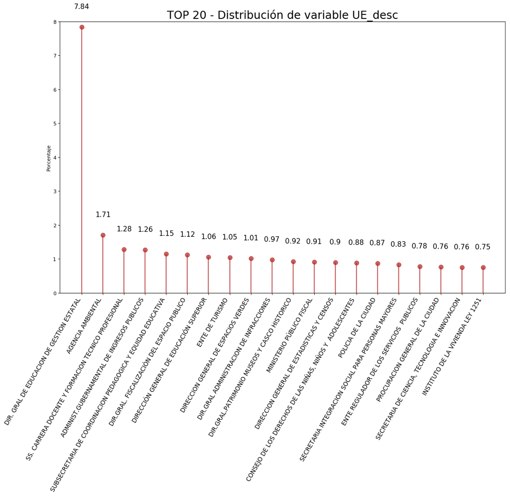

```python
df_datos = df_datos.rename(columns={'UE_desc':'Etiquetas'}).head(20).reset_index()
fig, ax = plt.subplots(figsize=(16,10), dpi= 80)
ax.vlines(x=df_datos.index, ymin=0, ymax=df_datos.Porcentaje, color='firebrick', alpha=0.7, linewidth=2)
ax.scatter(x=df_datos.index, y=df_datos.Porcentaje, s=75, color='firebrick', alpha=0.7)
ax.set_title('TOP 20 - Distribución de variable UE_desc', fontdict={'size':22})
ax.set_ylabel('Porcentaje')
ax.set_xticks(df_datos.index)
ax.set_xticklabels(df_datos.Etiquetas.str.upper(), rotation=60, fontdict={'horizontalalignment': 'right', 'size':12})
ax.set_ylim(0, 8)
for row in df_datos.itertuples():
    ax.text(row.Index, row.Porcentaje+.5, s=round(row.Porcentaje, 2), horizontalalignment= 'center', verticalalignment='bottom', fontsize=14)

plt.show()
```

Análisis sobre la variableProg_desc

```python
df_datos = presupuesto[["Prog_desc"]].groupby(["Prog_desc"])["Prog_desc"].count().reset_index(name='Cantidad')
df_datos["Porcentaje"] = df_datos["Cantidad"]/df_datos["Cantidad"].sum() * 100
df_datos = df_datos.sort_values(by="Cantidad", ascending = False)
display(df_datos)
```

|  | Prog_desc | Cantidad | Porcentaje |
| --- | --- | --- | --- |
| 131 | Atención Médica General En Hospitales De Agudos | 1915 | 3.924 |
| 237 | Educacion Primaria | 1252 | 2.566 |
| 235 | Educacion Inicial | 855 | 1.752 |
| 129 | Atención De Salud Mental | 696 | 1.426 |
| 233 | Educacion Del Adulto Y Del Adolescente | 588 | 1.205 |
| 195 | Cuidado Y Puesta En Valor De Espacios Verdes | 495 | 1.014 |
| 130 | Atención Médica De Patologías Específicas | 491 | 1.006 |
| 85 | Administracion De Infracciones En La Ciudad | 474 | 0.971 |
| 236 | Educacion Media | 437 | 0.895 |
| 494 | Sistema Estadístico De La Ciudad. | 435 | 0.891 |
| 480 | Sanidad Y Tenencia Responsable De Mascotas | 426 | 0.873 |
| 132 | Atención Médica Materno Infantil | 426 | 0.873 |
| 402 | Policía De La Ciudad | 424 | 0.869 |
| 18 | Actividades Centrales | 421 | 0.863 |
| 128 | Atención De Rehabilitación | 365 | 0.748 |
| 347 | Intervenciones De Recuperación Del Espacio Pub... | 343 | 0.703 |
| 234 | Educacion Especial | 318 | 0.652 |
| 479 | Salud Comunitaria - Centros De Salud | 313 | 0.641 |
| 37 | Actividades Comunes A Los Programas 91, 92, 9... | 307 | 0.629 |
| 110 | Asistencia Alimentaria Y Accion Comunitaria | 298 | 0.611 |
| 335 | Infraestructura Escolar | 294 | 0.602 |
| 156 | Comunicacion De La Cultura En Museos | 294 | 0.602 |
| 134 | Atención Odontológica General | 293 | 0.600 |
| 437 | Protección Y Sanidad Animal | 281 | 0.576 |
| 149 | Certificacion De La Identidad Y Capacidad De L... | 274 | 0.561 |
| 448 | Recaudación Tributaria. | 268 | 0.549 |
| 239 | Educacion Tecnica | 262 | 0.537 |
| 230 | Educacion Artistica | 255 | 0.523 |
| 133 | Atención Médica Oftalmológica | 251 | 0.514 |
| 27 | Actividades Centrales Hacienda | 247 | 0.506 |
| ... | ... | ... | ... |
| 376 | Obras Infraestructura Urbana En Red De Subterr... | 5 | 0.010 |
| 439 | Proyectos Con Financiamiento Estructurado | 5 | 0.010 |
| 410 | Premios Y Subsidios | 5 | 0.010 |
| 254 | Estrategia Y Fortalecimiento Territorial | 5 | 0.010 |
| 106 | Articulación Y Fortalecimiento De Gestión | 5 | 0.010 |
| 465 | Registro Verificación De Autopartes | 4 | 0.008 |
| 82 | Actualizacion Tecnologica Del Teatro Colon | 4 | 0.008 |
| 150 | Colonia Sola | 3 | 0.006 |
| 192 | Creditos 1ra Vivienda | 3 | 0.006 |
| 333 | Infraestructura De Sistemas De Transporte | 3 | 0.006 |
| 17 | Actividades Casa De La Cultura | 3 | 0.006 |
| 215 | Desarrollo Y Fomento De La Ciencia Y Tecnologia | 3 | 0.006 |
| 387 | Plan Nacional De Estadistica | 3 | 0.006 |
| 427 | Promocion Y Proteccion De Bares Notables | 3 | 0.006 |
| 191 | Corporacion Buenos Aires Sur S.E | 2 | 0.004 |
| 190 | Corporacion Bs.As Sur S.E | 2 | 0.004 |
| 325 | Hotelados | 2 | 0.004 |
| 405 | Políticas De Bienestar Ciudadano | 2 | 0.004 |
| 102 | Aportes Con Fines Sociales | 2 | 0.004 |
| 276 | Fondo De Emergencia Para Subsidios Por Inundac... | 2 | 0.004 |
| 263 | Facturación Y Cobranza De Los Efectores Públic... | 1 | 0.002 |
| 99 | Aplicacion Ley 4004 | 1 | 0.002 |
| 141 | Capacitación A Conductores Profesionales De Taxis | 1 | 0.002 |
| 413 | Procrear | 1 | 0.002 |
| 365 | Microcreditos | 1 | 0.002 |
| 324 | Hospital De Pediatría Juan Pedro Garrahan | 1 | 0.002 |
| 272 | Fomento Al Desarrollo Socio-Economico De La Co... | 1 | 0.002 |
| 273 | Fomento Al Desarrollo Socio-Económico | 1 | 0.002 |
| 284 | Formación En Seguridad | 1 | 0.002 |
| 246 | Ente Publico Espacio Para La Memoria | 1 | 0.002 |

510 rows × 3 columns

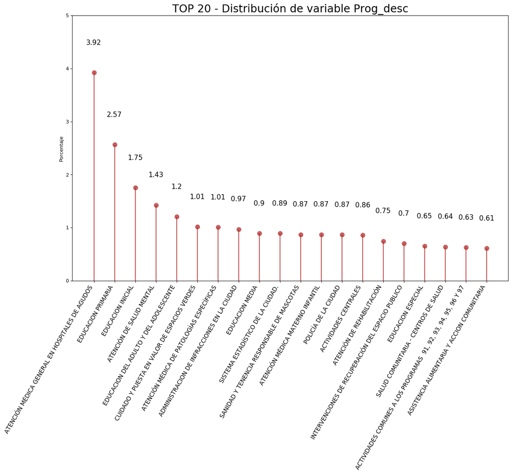

```python
df_datos = df_datos.rename(columns={'Prog_desc':'Etiquetas'}).head(20).reset_index()
fig, ax = plt.subplots(figsize=(16,10), dpi= 80)
ax.vlines(x=df_datos.index, ymin=0, ymax=df_datos.Porcentaje, color='firebrick', alpha=0.7, linewidth=2)
ax.scatter(x=df_datos.index, y=df_datos.Porcentaje, s=75, color='firebrick', alpha=0.7)
ax.set_title('TOP 20 - Distribución de variable Prog_desc', fontdict={'size':22})
ax.set_ylabel('Porcentaje')
ax.set_xticks(df_datos.index)
ax.set_xticklabels(df_datos.Etiquetas.str.upper(), rotation=60, fontdict={'horizontalalignment': 'right', 'size':12})
ax.set_ylim(0, 5)
for row in df_datos.itertuples():
    ax.text(row.Index, row.Porcentaje+.5, s=round(row.Porcentaje, 2), horizontalalignment= 'center', verticalalignment='bottom', fontsize=14)

plt.show()
```

Análisis sobre la variable Sprog_desc

```python
df_datos = df_categoricas[["Sprog_desc"]].groupby(["Sprog_desc"])["Sprog_desc"].count().reset_index(name='Cantidad')
df_datos["Porcentaje"] = df_datos["Cantidad"]/df_datos["Cantidad"].sum() * 100
df_datos = df_datos.sort_values(by="Cantidad", ascending = False)
display(df_datos)
```

|  | Sprog_desc | Cantidad | Porcentaje |
| --- | --- | --- | --- |
| 245 | Educacion Primaria | 1252 | 2.566 |
| 243 | Educacion Inicial | 855 | 1.752 |
| 241 | Educacion Del Adulto Y Del Adolescente | 588 | 1.205 |
| 203 | Cuidado Y Puesta En Valor De Espacios Verdes | 495 | 1.014 |
| 85 | Administracion De Infracciones En La Ciudad | 474 | 0.971 |
| 244 | Educacion Media | 437 | 0.895 |
| 536 | Sistema Estadístico De La Ciudad. | 435 | 0.891 |
| 522 | Sanidad Y Tenencia Responsable De Mascotas | 426 | 0.873 |
| 445 | Policía De La Ciudad | 424 | 0.869 |
| 18 | Actividades Centrales | 421 | 0.863 |
| 388 | Intervenciones De Recuperación Del Espacio Pub... | 343 | 0.703 |
| 242 | Educacion Especial | 318 | 0.652 |
| 37 | Actividades Comunes A Los Programas 91, 92, 9... | 307 | 0.629 |
| 110 | Asistencia Alimentaria Y Accion Comunitaria | 298 | 0.611 |
| 164 | Comunicacion De La Cultura En Museos | 294 | 0.602 |
| 375 | Infraestructura Escolar | 294 | 0.602 |
| 480 | Protección Y Sanidad Animal | 281 | 0.576 |
| 157 | Certificacion De La Identidad Y Capacidad De L... | 274 | 0.561 |
| 491 | Recaudación Tributaria. | 268 | 0.549 |
| 247 | Educacion Tecnica | 262 | 0.537 |
| 238 | Educacion Artistica | 255 | 0.523 |
| 27 | Actividades Centrales Hacienda | 247 | 0.506 |
| 441 | Planificación Sanitaria | 233 | 0.477 |
| 205 | Custodia Y Seguridad De Edificios Publicos | 225 | 0.461 |
| 401 | Mediacion Vecinal | 221 | 0.453 |
| 287 | Formacion Docente | 218 | 0.447 |
| 240 | Educacion De Gestion Privada | 213 | 0.436 |
| 251 | Emisión De Licencias | 210 | 0.430 |
| 289 | Formacion Laboral | 209 | 0.428 |
| 397 | Mantenimiento De La Red Pluvial | 209 | 0.428 |
| ... | ... | ... | ... |
| 101 | Aportes A Entes Publicos | 5 | 0.010 |
| 417 | Obras Infraestructura Urbana En Red De Subterr... | 5 | 0.010 |
| 262 | Estrategia Y Fortalecimiento Territorial | 5 | 0.010 |
| 82 | Actualizacion Tecnologica Del Teatro Colon | 4 | 0.008 |
| 508 | Registro Verificación De Autopartes | 4 | 0.008 |
| 373 | Infraestructura De Sistemas De Transporte | 3 | 0.006 |
| 200 | Creditos 1ra Vivienda | 3 | 0.006 |
| 223 | Desarrollo Y Fomento De La Ciencia Y Tecnologia | 3 | 0.006 |
| 158 | Colonia Sola | 3 | 0.006 |
| 429 | Plan Nacional De Estadistica | 3 | 0.006 |
| 17 | Actividades Casa De La Cultura | 3 | 0.006 |
| 470 | Promocion Y Proteccion De Bares Notables | 3 | 0.006 |
| 448 | Políticas De Bienestar Ciudadano | 2 | 0.004 |
| 199 | Corporacion Buenos Aires Sur S.E | 2 | 0.004 |
| 198 | Corporacion Bs.As Sur S.E | 2 | 0.004 |
| 284 | Fondo De Emergencia Para Subsidios Por Inundac... | 2 | 0.004 |
| 365 | Hotelados | 2 | 0.004 |
| 102 | Aportes Con Fines Sociales | 2 | 0.004 |
| 341 | Hospital De Pediatría Juan Pedro Garrahan | 1 | 0.002 |
| 406 | Microcreditos | 1 | 0.002 |
| 281 | Fomento Al Desarrollo Socio-Económico | 1 | 0.002 |
| 280 | Fomento Al Desarrollo Socio-Economico De La Co... | 1 | 0.002 |
| 136 | Capacitación A Conductores Profesionales De Taxis | 1 | 0.002 |
| 271 | Facturación Y Cobranza De Los Efectores Públic... | 1 | 0.002 |
| 292 | Formación En Seguridad | 1 | 0.002 |
| 99 | Aplicacion Ley 4004 | 1 | 0.002 |
| 254 | Ente Publico Espacio Para La Memoria | 1 | 0.002 |
| 521 | Salud Comunitaria - Acumar | 1 | 0.002 |
| 456 | Procrear | 1 | 0.002 |
| 129 | Atención Médica General En Hospitales De Agudos | 1 | 0.002 |

553 rows × 3 columns

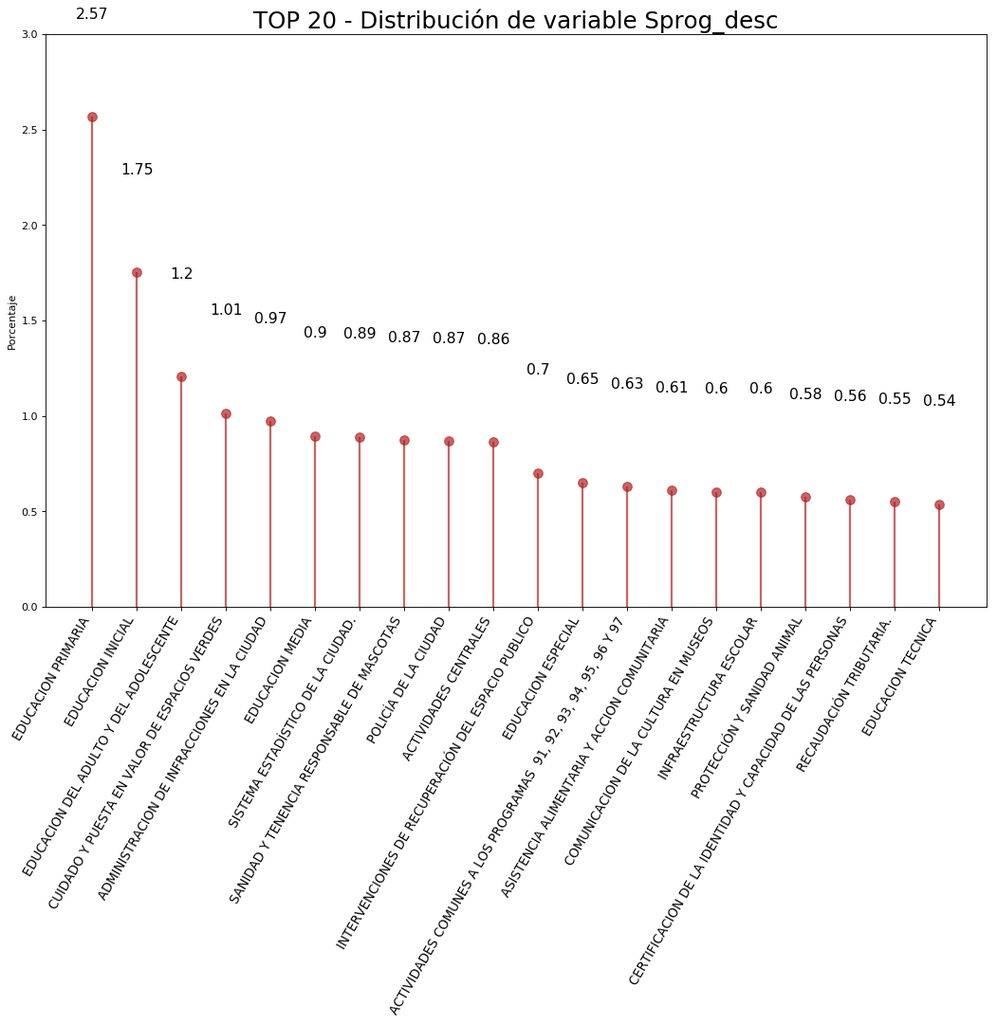

```python
df_datos = df_datos.rename(columns={'Sprog_desc':'Etiquetas'}).head(20).reset_index()
fig, ax = plt.subplots(figsize=(16,10), dpi= 80)
ax.vlines(x=df_datos.index, ymin=0, ymax=df_datos.Porcentaje, color='firebrick', alpha=0.7, linewidth=2)
ax.scatter(x=df_datos.index, y=df_datos.Porcentaje, s=75, color='firebrick', alpha=0.7)
ax.set_title('TOP 20 - Distribución de variable Sprog_desc', fontdict={'size':22})
ax.set_ylabel('Porcentaje')
ax.set_xticks(df_datos.index)
ax.set_xticklabels(df_datos.Etiquetas.str.upper(), rotation=60, fontdict={'horizontalalignment': 'right', 'size':12})
ax.set_ylim(0, 3)
for row in df_datos.itertuples():
    ax.text(row.Index, row.Porcentaje+.5, s=round(row.Porcentaje, 2), horizontalalignment= 'center', verticalalignment='bottom', fontsize=14)

plt.show()
```

Análisis sobre la variable Proy_desc

```python
df_datos = df_categoricas[["Proy_desc"]].groupby(["Proy_desc"])["Proy_desc"].count().reset_index(name='Cantidad')
df_datos["Porcentaje"] = df_datos["Cantidad"]/df_datos["Cantidad"].sum() * 100
df_datos = df_datos.sort_values(by="Cantidad", ascending = False)
display(df_datos)
```

|  | Proy_desc | Cantidad | Porcentaje |
| --- | --- | --- | --- |
| 306 | Educacion Primaria | 1252 | 2.566 |
| 304 | Educacion Inicial | 855 | 1.752 |
| 302 | Educacion Del Adulto Y Del Adolescente | 588 | 1.205 |
| 103 | Administracion De Infracciones En La Ciudad | 474 | 0.971 |
| 305 | Educacion Media | 437 | 0.895 |
| 758 | Sistema Estadístico De La Ciudad. | 433 | 0.887 |
| 738 | Sanidad Y Tenencia Responsable De Mascotas | 426 | 0.873 |
| 25 | Actividades Centrales | 411 | 0.842 |
| 257 | Cuidado Y Puesta En Valor De Espacios Verdes | 366 | 0.750 |
| 588 | Policía De La Ciudad | 359 | 0.736 |
| 472 | Intervenciones De Recuperación Del Espacio Pub... | 343 | 0.703 |
| 303 | Educacion Especial | 318 | 0.652 |
| 44 | Actividades Comunes A Los Programas 91, 92, 9... | 307 | 0.629 |
| 137 | Asistencia Alimentaria Y Accion Comunitaria | 298 | 0.611 |
| 201 | Comunicacion De La Cultura En Museos | 292 | 0.598 |
| 623 | Protección Y Sanidad Animal | 281 | 0.576 |
| 192 | Certificacion De La Identidad Y Capacidad De L... | 274 | 0.561 |
| 684 | Recaudación Tributaria. | 268 | 0.549 |
| 308 | Educacion Tecnica | 262 | 0.537 |
| 299 | Educacion Artistica | 255 | 0.523 |
| 34 | Actividades Centrales Hacienda | 247 | 0.506 |
| 259 | Custodia Y Seguridad De Edificios Publicos | 225 | 0.461 |
| 500 | Mediacion Vecinal | 221 | 0.453 |
| 362 | Formacion Docente | 218 | 0.447 |
| 584 | Planificación Sanitaria | 216 | 0.443 |
| 301 | Educacion De Gestion Privada | 213 | 0.436 |
| 364 | Formacion Laboral | 209 | 0.428 |
| 312 | Emisión De Licencias | 205 | 0.420 |
| 471 | Intervenciones De Fiscalización En La Vía Pública | 202 | 0.414 |
| 388 | Gestión De La Actividad Judicial Y Administrativa | 195 | 0.400 |
| ... | ... | ... | ... |
| 356 | Fomento Al Desarrollo Socio-Económico | 1 | 0.002 |
| 691 | Recursos Tecnologicos | 1 | 0.002 |
| 372 | Fortalecimiento Del Sistema De Administracion ... | 1 | 0.002 |
| 420 | Hospital De Pediatría Juan Pedro Garrahan | 1 | 0.002 |
| 298 | Edificios Apoyo A La Seguridad Publica | 1 | 0.002 |
| 668 | Puesta En Valor Hospital Ramón Sardá | 1 | 0.002 |
| 667 | Puesta En Valor Hospital Pedro Lagleyze | 1 | 0.002 |
| 717 | Reingenieria Integral Procesos Desarrollo Evol... | 1 | 0.002 |
| 373 | Fortalecimiento Gestional Del Ministerio De De... | 1 | 0.002 |
| 737 | Salud Comunitaria - Acumar | 1 | 0.002 |
| 655 | Puesta En Valor Hospital Donación Francisco Sa... | 1 | 0.002 |
| 656 | Puesta En Valor Hospital Enrique Tornú | 1 | 0.002 |
| 255 | Cuenca Del Arroyo Medrano | 1 | 0.002 |
| 657 | Puesta En Valor Hospital Francisco J. Muñiz | 1 | 0.002 |
| 658 | Puesta En Valor Hospital Ignacio Pirovano | 1 | 0.002 |
| 731 | Reparacion Y Mejoras En Barrios De Buenos Aires | 1 | 0.002 |
| 730 | Remodelación Integral Obra Sede Belgrano 838/4... | 1 | 0.002 |
| 729 | Remodelacion Edificio Flota Automotor | 1 | 0.002 |
| 659 | Puesta En Valor Hospital J. M. Penna | 1 | 0.002 |
| 660 | Puesta En Valor Hospital José M. Ramos Mejía | 1 | 0.002 |
| 264 | Desarrollo Capital Humano | 1 | 0.002 |
| 661 | Puesta En Valor Hospital Juan A. Fernández | 1 | 0.002 |
| 724 | Rellenado Y Reparación De Pozos En Aceras | 1 | 0.002 |
| 662 | Puesta En Valor Hospital Manuel Rocca | 1 | 0.002 |
| 663 | Puesta En Valor Hospital Maria Curie | 1 | 0.002 |
| 273 | Desarrollo Implementacion Tableros Predictivos... | 1 | 0.002 |
| 664 | Puesta En Valor Hospital Oftalmológico Santa L... | 1 | 0.002 |
| 665 | Puesta En Valor Hospital Parmenio Piñero | 1 | 0.002 |
| 666 | Puesta En Valor Hospital Pedro De Elizalde | 1 | 0.002 |
| 367 | Formación En Seguridad | 1 | 0.002 |

791 rows × 3 columns

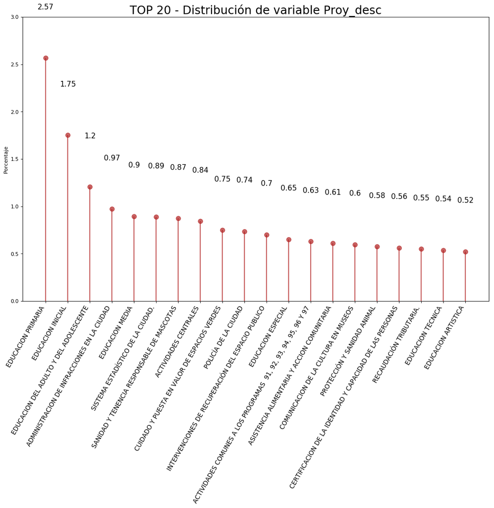

```python
df_datos = df_datos.rename(columns={'Proy_desc':'Etiquetas'}).head(20).reset_index()
fig, ax = plt.subplots(figsize=(16,10), dpi= 80)
ax.vlines(x=df_datos.index, ymin=0, ymax=df_datos.Porcentaje, color='firebrick', alpha=0.7, linewidth=2)
ax.scatter(x=df_datos.index, y=df_datos.Porcentaje, s=75, color='firebrick', alpha=0.7)
ax.set_title('TOP 20 - Distribución de variable Proy_desc', fontdict={'size':22})
ax.set_ylabel('Porcentaje')
ax.set_xticks(df_datos.index)
ax.set_xticklabels(df_datos.Etiquetas.str.upper(), rotation=60, fontdict={'horizontalalignment': 'right', 'size':12})
ax.set_ylim(0, 3)
for row in df_datos.itertuples():
    ax.text(row.Index, row.Porcentaje+.5, s=round(row.Porcentaje, 2), horizontalalignment= 'center', verticalalignment='bottom', fontsize=14)

plt.show()
```

Análisis sobre la variable Act_desc

```python
df_datos = df_categoricas[["Act_desc"]].groupby(["Act_desc"])["Act_desc"].count().reset_index(name='Cantidad')
df_datos["Porcentaje"] = df_datos["Cantidad"]/df_datos["Cantidad"].sum() * 100
df_datos = df_datos.sort_values(by="Cantidad", ascending = False)
display(df_datos)
```

|  | Act_desc | Cantidad | Porcentaje |
| --- | --- | --- | --- |
| 85 | Administración Y Servicios Generales | 5305 | 10.871 |
| 387 | Conducción | 4950 | 10.143 |
| 386 | Conduccion | 4377 | 8.969 |
| 71 | Administracion Y Servicios Generales | 3117 | 6.387 |
| 389 | Conducción Y Administración | 1399 | 2.867 |
| 1492 | Servicios De Diagnóstico Y Tratamiento | 887 | 1.818 |
| 1498 | Servicios Generales De Mantenimiento | 534 | 1.094 |
| 221 | Atención Ambulatoria - Consultorio Externo | 453 | 0.928 |
| 1493 | Servicios De Internación | 398 | 0.816 |
| 932 | Mantenimiento Comunal | 396 | 0.811 |
| 1610 | Urgencias | 395 | 0.809 |
| 892 | Jornada Completa | 315 | 0.645 |
| 857 | Instituciones De Educacion Media | 313 | 0.641 |
| 894 | Jornada Simple | 313 | 0.641 |
| 21 | Acciones Socioculturales | 306 | 0.627 |
| 887 | Jardines Integrales, Nucleados Y Comunes | 300 | 0.615 |
| 1091 | Oca | 290 | 0.594 |
| 634 | Escuelas Infantiles | 264 | 0.541 |
| 301 | Capacitación Y Docencia | 257 | 0.527 |
| 633 | Escuelas Especiales | 256 | 0.525 |
| 888 | Jardines Maternales | 250 | 0.512 |
| 628 | Erradicación De La Venta Ilegal | 248 | 0.508 |
| 636 | Escuelas Plurilingües | 233 | 0.477 |
| 1454 | Sanidad Animal | 227 | 0.465 |
| 858 | Instituciones De Educacion Media Tecnica | 222 | 0.455 |
| 86 | Administración Y Servicios Generales. | 218 | 0.447 |
| 1594 | Unidad De Auditoria Interna | 212 | 0.434 |
| 589 | Educacion Primaria | 208 | 0.426 |
| 586 | Educacion Media | 204 | 0.418 |
| 785 | Gestión Operativa Y Servicios Esenciales | 190 | 0.389 |
| ... | ... | ... | ... |
| 1031 | Municiones | 1 | 0.002 |
| 1049 | Nuestras Familias Nos Visitan | 1 | 0.002 |
| 1052 | Nuevo Código De Habilitaciones | 1 | 0.002 |
| 1055 | Objeto Fiscalizable Gcaba 100% Sade | 1 | 0.002 |
| 1014 | Mirador Comastri - Cine Del Plata | 1 | 0.002 |
| 1068 | Obras De Regeneracion Urbana | 1 | 0.002 |
| 1071 | Obras En Edificio Tribunal Superior De Justicia | 1 | 0.002 |
| 1072 | Obras En Edificios Administrativos Ministerio ... | 1 | 0.002 |
| 1089 | Observatorio De Políticas Metropolitanas - Opm | 1 | 0.002 |
| 1096 | Onsultoria Proyecto Ejecutivoeadec. Ex Carcel ... | 1 | 0.002 |
| 1097 | Operacion Centros De Transferencia | 1 | 0.002 |
| 1015 | Misa Criolla | 1 | 0.002 |
| 1013 | Microcreditos | 1 | 0.002 |
| 958 | Mantenimiento Servicio De Storage | 1 | 0.002 |
| 982 | Med | 1 | 0.002 |
| 959 | Mantenimiento Servidores Hp | 1 | 0.002 |
| 960 | Mantenimiento Sw Wily Intescope | 1 | 0.002 |
| 972 | Mantenimiento Y Reparación Edilicia | 1 | 0.002 |
| 979 | Master Plan General Paz | 1 | 0.002 |
| 980 | Masticar | 1 | 0.002 |
| 981 | Mecanismo De Evaluación Para Ingreso Y Permane... | 1 | 0.002 |
| 988 | Mejora En Los Procesos Administrativos | 1 | 0.002 |
| 1011 | Mi Escuela Saludable | 1 | 0.002 |
| 989 | Mejora Evolutiva En Modulos Sade | 1 | 0.002 |
| 994 | Mejoramiento Del Hábitat En Villas Y N.H.T | 1 | 0.002 |
| 1004 | Mesa Cuatripartita De Obra Publica | 1 | 0.002 |
| 1006 | Mesa Tripartita Sectorial | 1 | 0.002 |
| 1007 | Mesas Cuatripartitas De Obra Publica | 1 | 0.002 |
| 1008 | Mesas Tripartitas Sectorial | 1 | 0.002 |
| 1651 | Área Metropolitana | 1 | 0.002 |

1652 rows × 3 columns

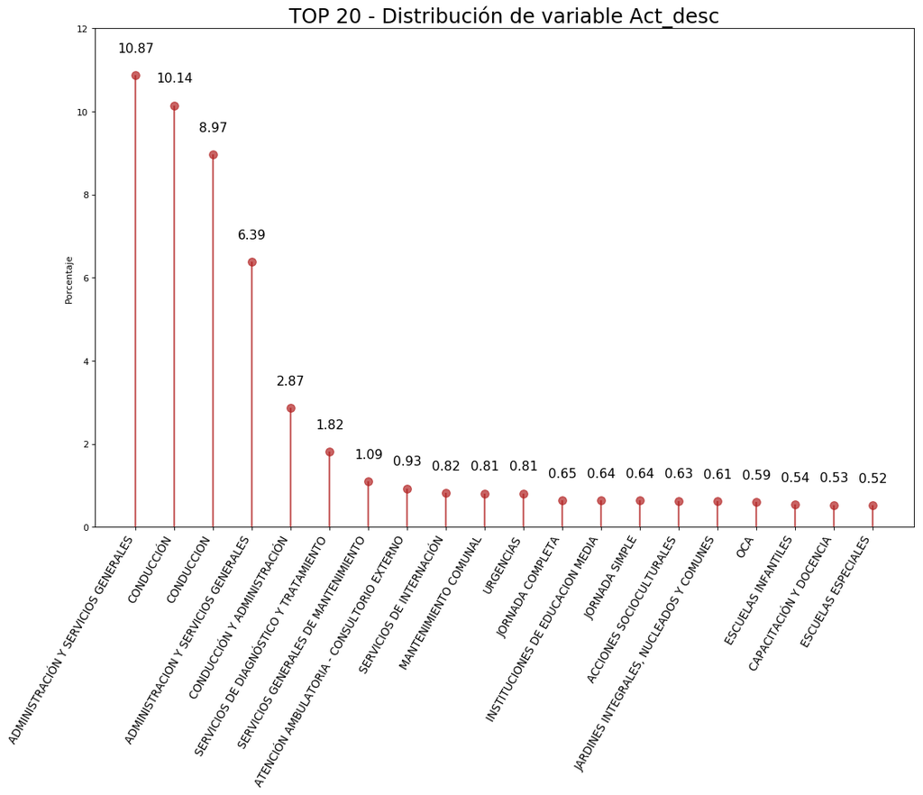

```python
df_datos = df_datos.rename(columns={'Act_desc':'Etiquetas'}).head(20).reset_index()
fig, ax = plt.subplots(figsize=(16,10), dpi= 80)
ax.vlines(x=df_datos.index, ymin=0, ymax=df_datos.Porcentaje, color='firebrick', alpha=0.7, linewidth=2)
ax.scatter(x=df_datos.index, y=df_datos.Porcentaje, s=75, color='firebrick', alpha=0.7)
ax.set_title('TOP 20 - Distribución de variable Act_desc', fontdict={'size':22})
ax.set_ylabel('Porcentaje')
ax.set_xticks(df_datos.index)
ax.set_xticklabels(df_datos.Etiquetas.str.upper(), rotation=60, fontdict={'horizontalalignment': 'right', 'size':12})
ax.set_ylim(0, 12)
for row in df_datos.itertuples():
    ax.text(row.Index, row.Porcentaje+.5, s=round(row.Porcentaje, 2), horizontalalignment= 'center', verticalalignment='bottom', fontsize=14)

plt.show()
```

Análisis sobre la variable ob_desc

```python
df_datos = df_categoricas[["ob_desc"]].groupby(["ob_desc"])["ob_desc"].count().reset_index(name='Cantidad')
df_datos["Porcentaje"] = df_datos["Cantidad"]/df_datos["Cantidad"].sum() * 100
df_datos = df_datos.sort_values(by="Cantidad", ascending = False)
display(df_datos)
```

|  | ob_desc | Cantidad | Porcentaje |
| --- | --- | --- | --- |
| 78 | Administración Y Servicios Generales | 5305 | 10.871 |
| 416 | Conducción | 4950 | 10.143 |
| 415 | Conduccion | 4377 | 8.969 |
| 64 | Administracion Y Servicios Generales | 3117 | 6.387 |
| 418 | Conducción Y Administración | 1399 | 2.867 |
| 1935 | Servicios De Diagnóstico Y Tratamiento | 887 | 1.818 |
| 1941 | Servicios Generales De Mantenimiento | 534 | 1.094 |
| 220 | Atención Ambulatoria - Consultorio Externo | 453 | 0.928 |
| 1936 | Servicios De Internación | 398 | 0.816 |
| 1196 | Mantenimiento Comunal | 396 | 0.811 |
| 2065 | Urgencias | 395 | 0.809 |
| 1148 | Jornada Completa | 315 | 0.645 |
| 1083 | Instituciones De Educacion Media | 313 | 0.641 |
| 1150 | Jornada Simple | 313 | 0.641 |
| 17 | Acciones Socioculturales | 306 | 0.627 |
| 1141 | Jardines Integrales, Nucleados Y Comunes | 300 | 0.615 |
| 1387 | Oca | 290 | 0.594 |
| 814 | Escuelas Infantiles | 264 | 0.541 |
| 315 | Capacitación Y Docencia | 257 | 0.527 |
| 813 | Escuelas Especiales | 256 | 0.525 |
| 1142 | Jardines Maternales | 250 | 0.512 |
| 699 | Erradicación De La Venta Ilegal | 248 | 0.508 |
| 817 | Escuelas Plurilingües | 233 | 0.477 |
| 1893 | Sanidad Animal | 227 | 0.465 |
| 1084 | Instituciones De Educacion Media Tecnica | 222 | 0.455 |
| 79 | Administración Y Servicios Generales. | 218 | 0.447 |
| 2050 | Unidad De Auditoria Interna | 212 | 0.434 |
| 650 | Educacion Primaria | 208 | 0.426 |
| 647 | Educacion Media | 204 | 0.418 |
| 971 | Gestión Operativa Y Servicios Esenciales | 190 | 0.389 |
| ... | ... | ... | ... |
| 1034 | Impresion Ampliacion Edificio Lezama | 1 | 0.002 |
| 1128 | Jardin De Infantes Integral N° 7 D.E. 20° - Li... | 1 | 0.002 |
| 1035 | Impresion Edificio Lezama | 1 | 0.002 |
| 1043 | Indumentaria Auxiliares De Porteria | 1 | 0.002 |
| 1053 | Infraestructura Basica Barrio Cildañez - Eje W... | 1 | 0.002 |
| 1054 | Infraestructura Basica Barrio La Carbonilla | 1 | 0.002 |
| 1056 | Infraestructura Basica Plaza Varela | 1 | 0.002 |
| 1057 | Infraestructura Basica Villa 1.11.14 Oceania Y... | 1 | 0.002 |
| 1058 | Infraestructura Basica Villa 21.24 Barrio Barr... | 1 | 0.002 |
| 1059 | Infraestructura Comunitaria Barrio Cildañez - ... | 1 | 0.002 |
| 1062 | Infreatructura Basica Villa 1.11.14 | 1 | 0.002 |
| 1070 | Inspeccion Barrios Tres Rosas Y San Blas | 1 | 0.002 |
| 1075 | Inspección De Inmuebles Abandonados | 1 | 0.002 |
| 1077 | Inst. De Form. Tec. Prof. Imagen, Sonido Y Com... | 1 | 0.002 |
| 1085 | Instituto Bernasconi Catulo Castillo 2750 - Ro... | 1 | 0.002 |
| 1087 | Instituto De Rehabilitacion Psicofisica Reestr... | 1 | 0.002 |
| 1088 | Instituto Pasteur - Reestructuracion Integral | 1 | 0.002 |
| 1090 | Instituto Superior De Lenguas Vivas - Carlos P... | 1 | 0.002 |
| 1094 | Integracion De Registros Y Sistema De Alertas ... | 1 | 0.002 |
| 1096 | Integración Con Apra | 1 | 0.002 |
| 1097 | Integración De Georeferenciación Y Datos Catas... | 1 | 0.002 |
| 1114 | Investigación | 1 | 0.002 |
| 1120 | Isef Nº 2 D.E. 8° "Prof. Federico Williams Dic... | 1 | 0.002 |
| 1121 | Jardin De Escuela Normal N° 5 D.E. 5° "Don Mar... | 1 | 0.002 |
| 1122 | Jardin De Infantes Comun D.E. 21 - Jose Ignaci... | 1 | 0.002 |
| 1123 | Jardin De Infantes Comun N° 1 D.E. 2 Arenales ... | 1 | 0.002 |
| 1125 | Jardin De Infantes Comun N° 4 D.E. 1° "Cinco E... | 1 | 0.002 |
| 1126 | Jardin De Infantes Integral D.E. 8° - Av. Eva ... | 1 | 0.002 |
| 1127 | Jardin De Infantes Integral N° 4 D.E. 15° - Bl... | 1 | 0.002 |
| 2110 | Área Metropolitana | 1 | 0.002 |

2111 rows × 3 columns

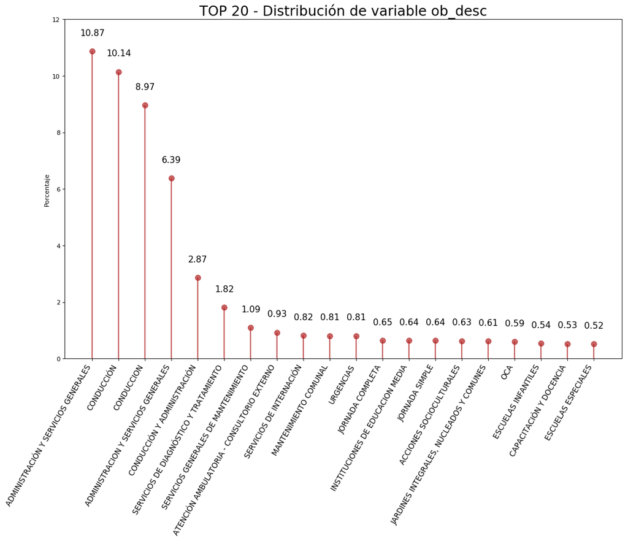

```python
df_datos = df_datos.rename(columns={'ob_desc':'Etiquetas'}).head(20).reset_index()
fig, ax = plt.subplots(figsize=(16,10), dpi= 80)
ax.vlines(x=df_datos.index, ymin=0, ymax=df_datos.Porcentaje, color='firebrick', alpha=0.7, linewidth=2)
ax.scatter(x=df_datos.index, y=df_datos.Porcentaje, s=75, color='firebrick', alpha=0.7)
ax.set_title('TOP 20 - Distribución de variable ob_desc', fontdict={'size':22})
ax.set_ylabel('Porcentaje')
ax.set_xticks(df_datos.index)
ax.set_xticklabels(df_datos.Etiquetas.str.upper(), rotation=60, fontdict={'horizontalalignment': 'right', 'size':12})
ax.set_ylim(0, 12)
for row in df_datos.itertuples():
    ax.text(row.Index, row.Porcentaje+.5, s=round(row.Porcentaje, 2), horizontalalignment= 'center', verticalalignment='bottom', fontsize=14)

plt.show()
```

Análisis sobre la variable Fin_desc

```python
df_datos = df_categoricas[["Fin_desc"]].groupby(["Fin_desc"])["Fin_desc"].count().reset_index(name='Cantidad')
df_datos["Porcentaje"] = df_datos["Cantidad"]/df_datos["Cantidad"].sum() * 100
df_datos = df_datos.sort_values(by="Cantidad", ascending = False)
display(df_datos)
```

|  | Fin_desc | Cantidad | Porcentaje |
| --- | --- | --- | --- |
| 4 | Servicios Sociales | 23214 | 47.569 |
| 0 | Administración Gubernamental | 13415 | 27.489 |
| 3 | Servicios Económicos | 7993 | 16.379 |
| 2 | Servicios De Seguridad | 4164 | 8.533 |
| 1 | Deuda Pública – Intereses Y Gastos | 15 | 0.031 |

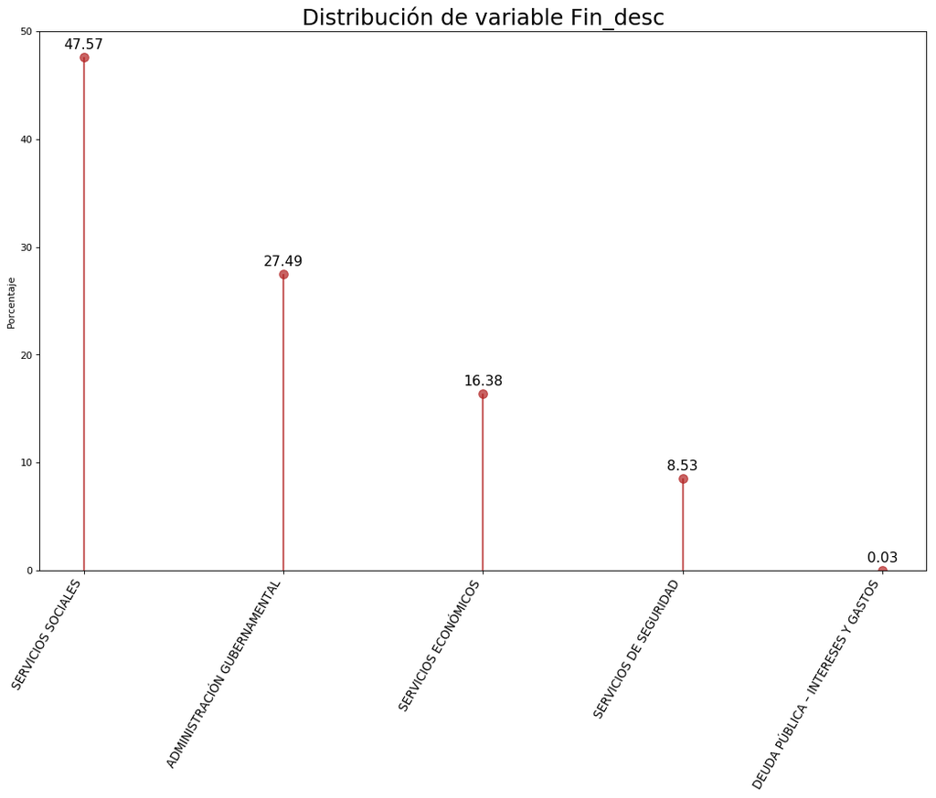

```python
df_datos = df_datos.rename(columns={'Fin_desc':'Etiquetas'}).head(20).reset_index()
fig, ax = plt.subplots(figsize=(16,10), dpi= 80)
ax.vlines(x=df_datos.index, ymin=0, ymax=df_datos.Porcentaje, color='firebrick', alpha=0.7, linewidth=2)
ax.scatter(x=df_datos.index, y=df_datos.Porcentaje, s=75, color='firebrick', alpha=0.7)
ax.set_title('Distribución de variable Fin_desc', fontdict={'size':22})
ax.set_ylabel('Porcentaje')
ax.set_xticks(df_datos.index)
ax.set_xticklabels(df_datos.Etiquetas.str.upper(), rotation=60, fontdict={'horizontalalignment': 'right', 'size':12})
ax.set_ylim(0, 50)
for row in df_datos.itertuples():
    ax.text(row.Index, row.Porcentaje+.5, s=round(row.Porcentaje, 2), horizontalalignment= 'center', verticalalignment='bottom', fontsize=14)

plt.show()
```

Análisis sobre la variable Fun_desc

```python
df_datos = df_categoricas[["Fun_desc"]].groupby(["Fun_desc"])["Fun_desc"].count().reset_index(name='Cantidad')
df_datos["Porcentaje"] = df_datos["Cantidad"]/df_datos["Cantidad"].sum() * 100
df_datos = df_datos.sort_values(by="Cantidad", ascending = False)
display(df_datos)
```

|  | Fun_desc | Cantidad | Porcentaje |
| --- | --- | --- | --- |
| 5 | Dirección Ejecutiva | 7497 | 15.362 |
| 7 | Educación | 7466 | 15.299 |
| 12 | Salud | 6179 | 12.662 |
| 11 | Promoción Y Acción Social | 4384 | 8.983 |
| 13 | Seguridad Interior | 4164 | 8.533 |
| 3 | Cultura | 3289 | 6.740 |
| 15 | Servicios Urbanos | 3127 | 6.408 |
| 6 | Ecología | 2537 | 5.199 |
| 9 | Judicial | 2343 | 4.801 |
| 0 | Administración Fiscal | 2097 | 4.297 |
| 2 | Control De La Gestión | 1399 | 2.867 |
| 8 | Industria Y Comercio | 1108 | 2.270 |
| 16 | Trabajo | 1000 | 2.049 |
| 17 | Transporte | 726 | 1.488 |
| 19 | Vivienda | 552 | 1.131 |
| 18 | Turismo | 491 | 1.006 |
| 1 | Agua Potable Y Alcantarillado | 344 | 0.705 |
| 10 | Legislativa | 79 | 0.162 |
| 4 | Deuda Pública – Intereses Y Gastos | 15 | 0.031 |
| 14 | Seguros Y Finanzas | 4 | 0.008 |

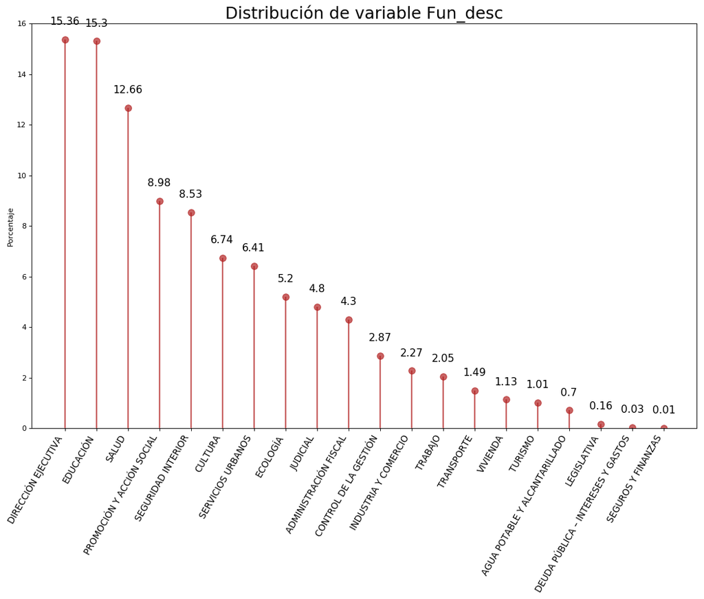

```python
df_datos = df_datos.rename(columns={'Fun_desc':'Etiquetas'}).head(20).reset_index()
fig, ax = plt.subplots(figsize=(16,10), dpi= 80)
ax.vlines(x=df_datos.index, ymin=0, ymax=df_datos.Porcentaje, color='firebrick', alpha=0.7, linewidth=2)
ax.scatter(x=df_datos.index, y=df_datos.Porcentaje, s=75, color='firebrick', alpha=0.7)
ax.set_title('Distribución de variable Fun_desc', fontdict={'size':22})
ax.set_ylabel('Porcentaje')
ax.set_xticks(df_datos.index)
ax.set_xticklabels(df_datos.Etiquetas.str.upper(), rotation=60, fontdict={'horizontalalignment': 'right', 'size':12})
ax.set_ylim(0, 16)
for row in df_datos.itertuples():
    ax.text(row.Index, row.Porcentaje+.5, s=round(row.Porcentaje, 2), horizontalalignment= 'center', verticalalignment='bottom', fontsize=14)

plt.show()
```

Análisis sobre la variable Inc_desc

```python
df_datos = df_categoricas[["Inc_desc"]].groupby(["Inc_desc"])["Inc_desc"].count().reset_index(name='Cantidad')
df_datos["Porcentaje"] = df_datos["Cantidad"]/df_datos["Cantidad"].sum() * 100
df_datos = df_datos.sort_values(by="Cantidad", ascending = False)
display(df_datos)
```

|  | Inc_desc | Cantidad | Porcentaje |
| --- | --- | --- | --- |
| 3 | Gastos En Personal | 16859 | 34.546 |
| 1 | Bienes De Consumo | 13690 | 28.053 |
| 5 | Servicios No Personales | 12587 | 25.793 |
| 2 | Bienes De Uso | 4086 | 8.373 |
| 6 | Transferencias | 1413 | 2.895 |
| 0 | Activos Financieros | 151 | 0.309 |
| 4 | Servicio De La Deuda Y Disminución De Otros Pa... | 15 | 0.031 |

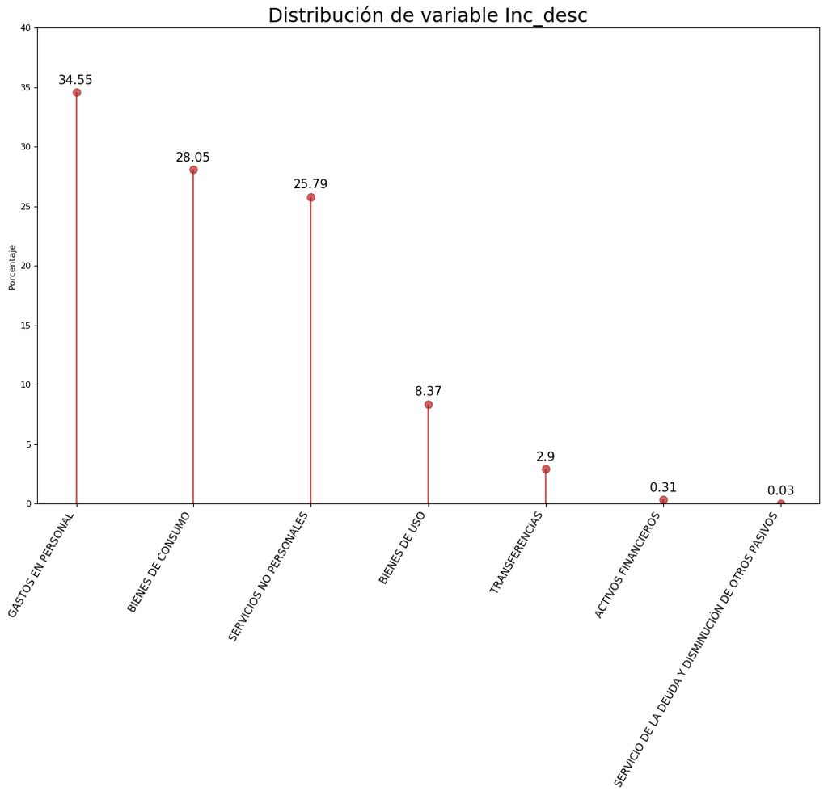

```python
df_datos = df_datos.rename(columns={'Inc_desc':'Etiquetas'}).head(20).reset_index()
fig, ax = plt.subplots(figsize=(16,10), dpi= 80)
ax.vlines(x=df_datos.index, ymin=0, ymax=df_datos.Porcentaje, color='firebrick', alpha=0.7, linewidth=2)
ax.scatter(x=df_datos.index, y=df_datos.Porcentaje, s=75, color='firebrick', alpha=0.7)
ax.set_title('Distribución de variable Inc_desc', fontdict={'size':22})
ax.set_ylabel('Porcentaje')
ax.set_xticks(df_datos.index)
ax.set_xticklabels(df_datos.Etiquetas.str.upper(), rotation=60, fontdict={'horizontalalignment': 'right', 'size':12})
ax.set_ylim(0, 40)
for row in df_datos.itertuples():
    ax.text(row.Index, row.Porcentaje+.5, s=round(row.Porcentaje, 2), horizontalalignment= 'center', verticalalignment='bottom', fontsize=14)

plt.show()
```

Análisis sobre la variable Ppal_desc

```python
df_datos = df_categoricas[["Ppal_desc"]].groupby(["Ppal_desc"])["Ppal_desc"].count().reset_index(name='Cantidad')
df_datos["Porcentaje"] = df_datos["Cantidad"]/df_datos["Cantidad"].sum() * 100
df_datos = df_datos.sort_values(by="Cantidad", ascending = False)
display(df_datos)
```

|  | Ppal_desc | Cantidad | Porcentaje |
| --- | --- | --- | --- |
| 22 | Personal Permanente | 6934 | 14.209 |
| 23 | Personal Transitorio | 4506 | 9.233 |
| 18 | Otros Bienes De Consumo | 4409 | 9.035 |
| 36 | Servicios Especializados, Comerciales Y Financ... | 3108 | 6.369 |
| 28 | Productos Químicos, Combustibles Y Lubricantes | 2787 | 5.711 |
| 14 | Mantenimiento, Reparación Y Limpieza | 2758 | 5.652 |
| 32 | Pulpa,Papel, Cartón Y Sus Productos | 2691 | 5.514 |
| 15 | Maquinaria Y Equipo | 2626 | 5.381 |
| 3 | Asignaciones Familiares | 1861 | 3.813 |
| 20 | Otros Servicios | 1830 | 3.750 |
| 4 | Asistencia Social Al Personal | 1645 | 3.371 |
| 1 | Alquileres Y Derechos | 1405 | 2.879 |
| 45 | Transferencias Al Sector Privado Para Financia... | 1323 | 2.711 |
| 21 | Pasajes, Viáticos Y Movilidad | 1236 | 2.533 |
| 24 | Productos Alimenticios, Agropecuarios Y Forest... | 1228 | 2.516 |
| 7 | Construcciones | 1121 | 2.297 |
| 35 | Servicios Básicos | 1026 | 2.102 |
| 10 | Gabinete De Autoridades Superiores | 1018 | 2.086 |
| 39 | Textiles Y Vestuario | 1015 | 2.080 |
| 38 | Servicios Profesionales, Técnicos Y Operativos | 946 | 1.938 |
| 27 | Productos Metálicos | 761 | 1.559 |
| 37 | Servicios Extraordinarios | 577 | 1.182 |
| 26 | Productos De Minerales No Metálicos | 540 | 1.107 |
| 8 | Contratos Por Tiempo Determinado | 278 | 0.570 |
| 11 | Impuestos, Derechos, Tasas Y Juicios | 191 | 0.391 |
| 0 | Activos Intangibles | 189 | 0.387 |
| 25 | Productos De Cuero Y Caucho | 151 | 0.309 |
| 12 | Incremento De Activos Diferidos Y Adelantos A ... | 122 | 0.250 |
| 16 | Minerales | 108 | 0.221 |
| 31 | Publicidad Y Propaganda | 87 | 0.178 |
| 17 | Obras De Arte, Libros Y Elementos Coleccionables | 81 | 0.166 |
| 5 | Beneficios Y Compensaciones | 40 | 0.082 |
| 43 | Transferencias A Universidades | 37 | 0.076 |
| 9 | Equipo De Seguridad | 33 | 0.068 |
| 19 | Otros Bienes De Uso E Inversiones | 29 | 0.059 |
| 30 | Préstamos A Largo Plazo | 27 | 0.055 |
| 44 | Transferencias Al Exterior | 17 | 0.035 |
| 47 | Transferencias Al Sector Público Empresarial | 16 | 0.033 |
| 40 | Transf A Instituciones Provinciales Y Municipa... | 8 | 0.016 |
| 46 | Transferencias Al Sector Privado Para Financia... | 8 | 0.016 |
| 33 | Servicio De La Deuda Externa | 7 | 0.014 |
| 6 | Bienes Preexistentes | 7 | 0.014 |
| 34 | Servicio De La Deuda Interna | 5 | 0.010 |
| 13 | Intereses Por Préstamos Y Otras Deudas | 3 | 0.006 |
| 42 | Transf.Al Sector Público Nacional Para Financi... | 3 | 0.006 |
| 41 | Transf.A Instituciones Provinciales Y Municipa... | 1 | 0.002 |
| 29 | Préstamos A Corto Plazo | 1 | 0.002 |
| 2 | Aportes De Capital | 1 | 0.002 |

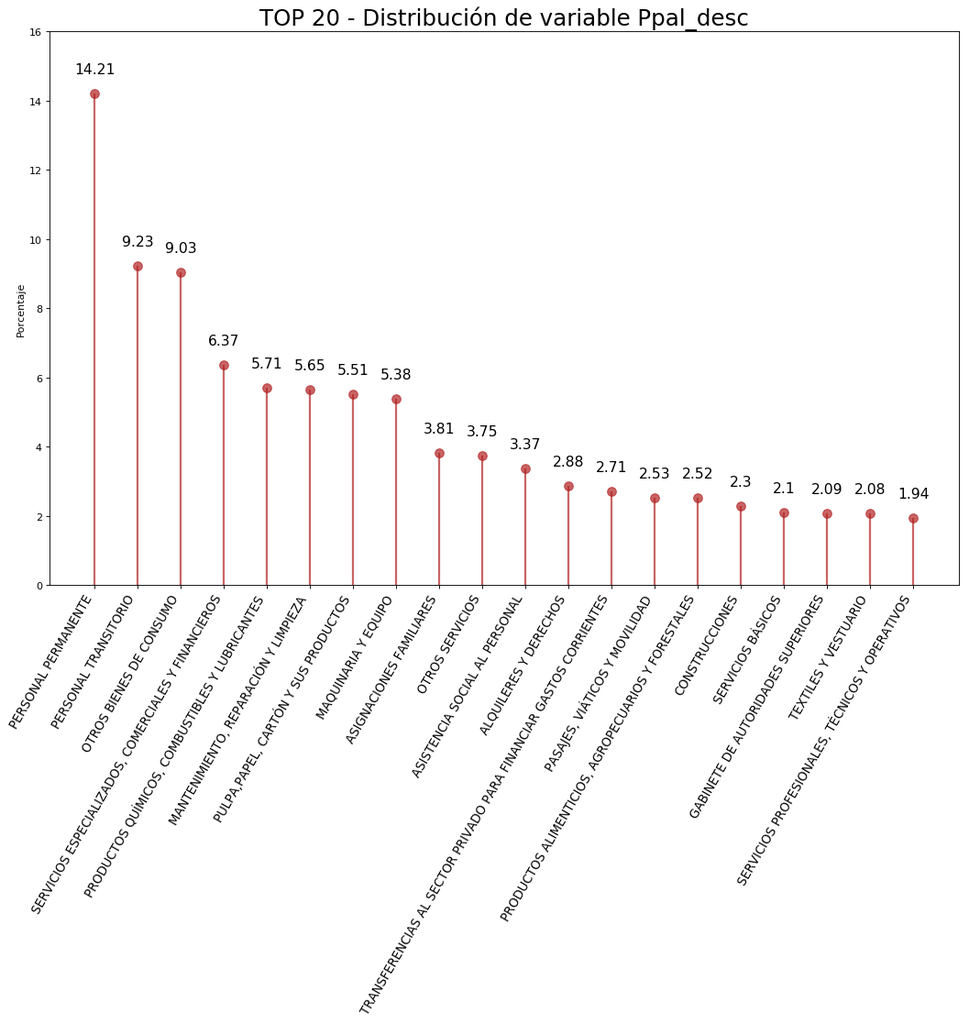

```python
df_datos = df_datos.rename(columns={'Ppal_desc':'Etiquetas'}).head(20).reset_index()
fig, ax = plt.subplots(figsize=(16,10), dpi= 80)
ax.vlines(x=df_datos.index, ymin=0, ymax=df_datos.Porcentaje, color='firebrick', alpha=0.7, linewidth=2)
ax.scatter(x=df_datos.index, y=df_datos.Porcentaje, s=75, color='firebrick', alpha=0.7)
# Title, Label, Ticks and Ylim
ax.set_title('TOP 20 - Distribución de variable Ppal_desc', fontdict={'size':22})
ax.set_ylabel('Porcentaje')
ax.set_xticks(df_datos.index)
ax.set_xticklabels(df_datos.Etiquetas.str.upper(), rotation=60, fontdict={'horizontalalignment': 'right', 'size':12})
ax.set_ylim(0, 16)
# Annotate
for row in df_datos.itertuples():
    ax.text(row.Index, row.Porcentaje+.5, s=round(row.Porcentaje, 2), horizontalalignment= 'center', verticalalignment='bottom', fontsize=14)

plt.show()
```

Análisis sobre la variable Par_desc

```python
df_datos = df_categoricas[["Par_desc"]].groupby(["Par_desc"])["Par_desc"].count().reset_index(name='Cantidad')
df_datos["Porcentaje"] = df_datos["Cantidad"]/df_datos["Cantidad"].sum() * 100
df_datos = df_datos.sort_values(by="Cantidad", ascending = False)
display(df_datos)
```

|  | Par_desc | Cantidad | Porcentaje |
| --- | --- | --- | --- |
| 97 | Otros No Especificados Precedentemente | 4902 | 10.045 |
| 132 | Retribución Del Cargo | 3253 | 6.666 |
| 32 | Contribuciones Patronales | 3249 | 6.658 |
| 144 | Sueldo Anual Complementario | 3209 | 6.576 |
| 26 | Complementos | 3061 | 6.272 |
| 134 | Seguros De Riesgo De Trabajo | 1621 | 3.322 |
| 103 | Personal Permanente | 1134 | 2.324 |
| 6 | Alimentos Para Personas | 993 | 2.035 |
| 168 | Útiles De Escritorio, Oficina Y Enseñanza | 962 | 1.971 |
| 118 | Productos Farmacéuticos Y Medicinales | 912 | 1.869 |
| 140 | Servicios Especializados | 850 | 1.742 |
| 99 | Papel Y Cartón Para Oficina | 771 | 1.580 |
| 63 | Imprenta, Publicaciones Y Reproducciones | 771 | 1.580 |
| 138 | Servicios De Comidas, Viandas Y Refrigerios | 718 | 1.471 |
| 89 | Movilidad | 696 | 1.426 |
| 104 | Personal Temporario | 659 | 1.350 |
| 51 | Equipo Para Computación | 651 | 1.334 |
| 29 | Construcciones En Bienes De Dominio Privado | 631 | 1.293 |
| 113 | Productos De Artes Gráficas | 617 | 1.264 |
| 127 | Repuestos Y Accesorios | 617 | 1.264 |
| 86 | Manufactura De Pulpa, Papel Y Cartíon | 607 | 1.244 |
| 83 | Mantenimiento Y Reparación De Maquinaria Y Equipo | 594 | 1.217 |
| 170 | Útiles Y Materiales Eléctricos | 580 | 1.189 |
| 47 | Equipo De Oficina Y Moblaje | 575 | 1.178 |
| 108 | Prendas De Vestir | 545 | 1.117 |
| 169 | Útiles Menores Médicos, Quirúrgicos Y De Labor... | 536 | 1.098 |
| 165 | Transporte Y Almacenamiento | 515 | 1.055 |
| 82 | Mantenimiento Y Reparación De Edificios Y Locales | 503 | 1.031 |
| 30 | Construcciones En Bienes De Dominio Público | 486 | 0.996 |
| 18 | Ayudas Sociales A Personas | 452 | 0.926 |
| ... | ... | ... | ... |
| 126 | Relleno Sanitario | 3 | 0.006 |
| 69 | Intereses De La Deuda Interna A Largo Plazo | 3 | 0.006 |
| 88 | Material De Guerra | 3 | 0.006 |
| 54 | Especies Timbradas Y Valores | 3 | 0.006 |
| 125 | Regalías | 3 | 0.006 |
| 160 | Transferencias A Otros Entes Del Sec.Púb.Gtos ... | 2 | 0.004 |
| 155 | Transferencias A Entes Tripartitos | 2 | 0.004 |
| 67 | Intereses De La Deuda Externa A Largo Plazo | 2 | 0.004 |
| 152 | Transf.A Organismos Internacionales Para Finan... | 2 | 0.004 |
| 141 | Servicios Varios Para Eventos Deportivos | 2 | 0.004 |
| 147 | Tierras Y Terrenos Para El Dominio Privado De ... | 2 | 0.004 |
| 71 | Intereses Por Préstamos Del Sector Público Nac... | 2 | 0.004 |
| 76 | Leasing | 2 | 0.004 |
| 1 | A Otras Instituciones Públicas Nacionales | 2 | 0.004 |
| 105 | Petróleo Crudo Y Gas Natural | 2 | 0.004 |
| 92 | Obras De Arte | 2 | 0.004 |
| 163 | Transferencias Otros Entes Sec.Públ.Gtos Capital | 1 | 0.002 |
| 11 | Aportes De Capital A Otros Entes Sec.Público | 1 | 0.002 |
| 122 | Préstamos A Corto Plazo Al Sector Privado | 1 | 0.002 |
| 109 | Primas De Emisión De Valores Públicos En Moned... | 1 | 0.002 |
| 21 | Carbón Mineral | 1 | 0.002 |
| 39 | Derechos De Bienes Intangibles | 1 | 0.002 |
| 68 | Intereses De La Deuda Interna A Corto Plazo - ... | 1 | 0.002 |
| 93 | Obras De Mejora Y Ampliación | 1 | 0.002 |
| 70 | Intereses Por Préstamos Del Sector Privado | 1 | 0.002 |
| 45 | Equiamiento Para Eventos Deportivos | 1 | 0.002 |
| 156 | Transferencias A Gobiernos Municipales | 1 | 0.002 |
| 73 | Jubilaciones Retiros Y/O Pensiones | 1 | 0.002 |
| 65 | Impuestos Indirectos | 1 | 0.002 |
| 0 | A La Administración Central Nacional | 1 | 0.002 |

171 rows × 3 columns

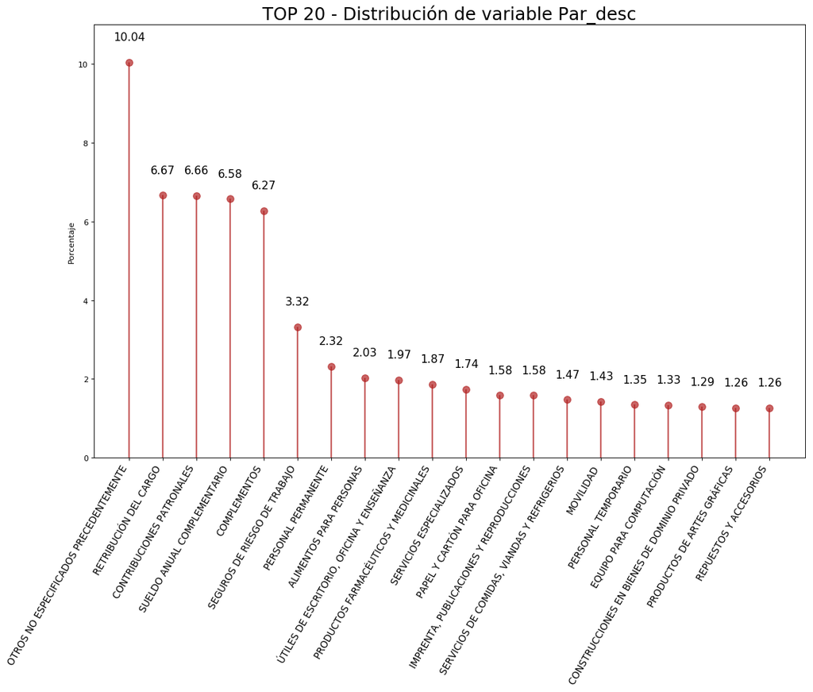

```python
df_datos = df_datos.rename(columns={'Par_desc':'Etiquetas'}).head(20).reset_index()
fig, ax = plt.subplots(figsize=(16,10), dpi= 80)
ax.vlines(x=df_datos.index, ymin=0, ymax=df_datos.Porcentaje, color='firebrick', alpha=0.7, linewidth=2)
ax.scatter(x=df_datos.index, y=df_datos.Porcentaje, s=75, color='firebrick', alpha=0.7)
ax.set_title('TOP 20 - Distribución de variable Par_desc', fontdict={'size':22})
ax.set_ylabel('Porcentaje')
ax.set_xticks(df_datos.index)
ax.set_xticklabels(df_datos.Etiquetas.str.upper(), rotation=60, fontdict={'horizontalalignment': 'right', 'size':12})
ax.set_ylim(0, 11)
for row in df_datos.itertuples():
    ax.text(row.Index, row.Porcentaje+.5, s=round(row.Porcentaje, 2), horizontalalignment= 'center', verticalalignment='bottom', fontsize=14)

plt.show()
```

Análisis sobre la variable Spar_desc

```python
df_datos = df_categoricas[["Spar_desc"]].groupby(["Spar_desc"])["Spar_desc"].count().reset_index(name='Cantidad')
df_datos["Porcentaje"] = df_datos["Cantidad"]/df_datos["Cantidad"].sum() * 100
df_datos = df_datos.sort_values(by="Cantidad", ascending = False)
display(df_datos)
```

|  | Spar_desc | Cantidad | Porcentaje |
| --- | --- | --- | --- |
| 249 | Otros No Especificados Precedentemente | 4902 | 10.045 |
| 300 | Retribución Del Cargo | 3253 | 6.666 |
| 115 | Contribuciones Patronales | 3249 | 6.658 |
| 325 | Sueldo Anual Complementario | 3209 | 6.576 |
| 106 | Complementos | 3061 | 6.272 |
| 304 | Seguros De Riesgo De Trabajo | 1621 | 3.322 |
| 257 | Personal Permanente | 1134 | 2.324 |
| 12 | Alimentos Para Personas | 993 | 2.035 |
| 349 | Útiles De Escritorio, Oficina Y Enseñanza | 962 | 1.971 |
| 281 | Productos Farmacéuticos Y Medicinales | 912 | 1.869 |
| 312 | Servicios Especializados | 850 | 1.742 |
| 251 | Papel Y Cartón Para Oficina | 771 | 1.580 |
| 193 | Imprenta, Publicaciones Y Reproducciones | 771 | 1.580 |
| 310 | Servicios De Comidas, Viandas Y Refrigerios | 718 | 1.471 |
| 231 | Movilidad | 696 | 1.426 |
| 258 | Personal Temporario | 659 | 1.350 |
| 152 | Equipo Para Computación | 651 | 1.334 |
| 112 | Construcciones En Bienes De Dominio Privado | 631 | 1.293 |
| 276 | Productos De Artes Gráficas | 617 | 1.264 |
| 295 | Repuestos Y Accesorios | 617 | 1.264 |
| 225 | Manufactura De Pulpa, Papel Y Cartíon | 607 | 1.244 |
| 222 | Mantenimiento Y Reparación De Maquinaria Y Equipo | 594 | 1.217 |
| 351 | Útiles Y Materiales Eléctricos | 580 | 1.189 |
| 148 | Equipo De Oficina Y Moblaje | 575 | 1.178 |
| 268 | Prendas De Vestir | 545 | 1.117 |
| 350 | Útiles Menores Médicos, Quirúrgicos Y De Labor... | 536 | 1.098 |
| 341 | Transporte Y Almacenamiento | 515 | 1.055 |
| 221 | Mantenimiento Y Reparación De Edificios Y Locales | 503 | 1.031 |
| 113 | Construcciones En Bienes De Dominio Público | 486 | 0.996 |
| 138 | Elementos De Limpieza | 442 | 0.906 |
| ... | ... | ... | ... |
| 56 | Asociación Igualdad De Derechos | 1 | 0.002 |
| 55 | Asociación Civil Liga Der.Del Hombre | 1 | 0.002 |
| 252 | Paradores | 1 | 0.002 |
| 253 | Parroquia Dulcisimo Nombre De Jesus | 1 | 0.002 |
| 54 | Asociación Civil "El Almendro" | 1 | 0.002 |
| 53 | Asociaciones De Consumidores | 1 | 0.002 |
| 64 | Becas Educación Especial | 1 | 0.002 |
| 216 | Liga Argentina Ddhh | 1 | 0.002 |
| 178 | Fund. Margarita Barrientos | 1 | 0.002 |
| 213 | Ley 4420 Subsidio A Bomberos | 1 | 0.002 |
| 179 | Fundación Arg.Transplante Hepáticos | 1 | 0.002 |
| 180 | Fundación Manos Abiertas | 1 | 0.002 |
| 182 | Goleta Del Bicentenario | 1 | 0.002 |
| 183 | Grupos Comunitarios | 1 | 0.002 |
| 184 | Habitantes De La Traza Ex Au 3 | 1 | 0.002 |
| 185 | Harvard Y Otros | 1 | 0.002 |
| 76 | Bienes Preexistentes | 1 | 0.002 |
| 75 | Bicicletas Mejores Promedios | 1 | 0.002 |
| 191 | Hospital Garrahan | 1 | 0.002 |
| 72 | Beneficiarios Ex Cassaba | 1 | 0.002 |
| 195 | Impuestos Indirectos | 1 | 0.002 |
| 196 | Incentivo A La Educación Técnica | 1 | 0.002 |
| 198 | Inmueble Eursp | 1 | 0.002 |
| 201 | Instituto Multimedia De Derechos Humanos | 1 | 0.002 |
| 202 | Intereses De La Deuda Externa A Largo Plazo-En... | 1 | 0.002 |
| 203 | Intereses De La Deuda Interna A Corto Plazo - ... | 1 | 0.002 |
| 206 | Jardines Maternales | 1 | 0.002 |
| 211 | Ley 1240 - Subsidio A Entidades De Bomberos | 1 | 0.002 |
| 212 | Ley 4004 | 1 | 0.002 |
| 0 | 'Subsidio Fundación ''El Pobre De Asís''' | 1 | 0.002 |

352 rows × 3 columns

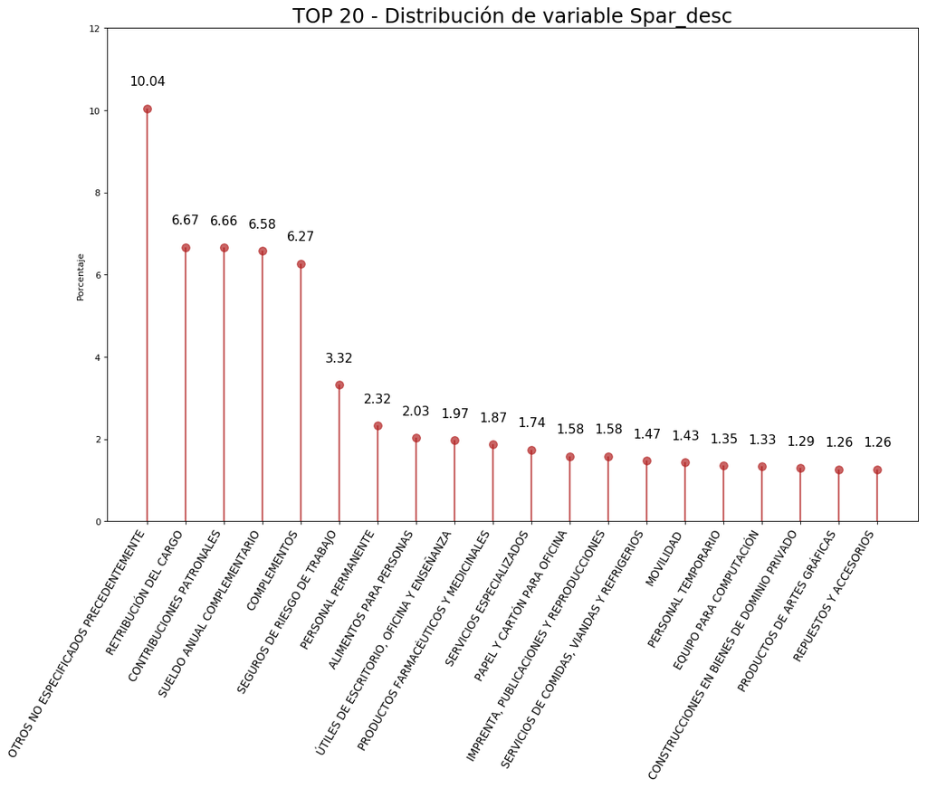

```python
df_datos = df_datos.rename(columns={'Spar_desc':'Etiquetas'}).head(20).reset_index()
fig, ax = plt.subplots(figsize=(16,10), dpi= 80)
ax.vlines(x=df_datos.index, ymin=0, ymax=df_datos.Porcentaje, color='firebrick', alpha=0.7, linewidth=2)
ax.scatter(x=df_datos.index, y=df_datos.Porcentaje, s=75, color='firebrick', alpha=0.7)
ax.set_title('TOP 20 - Distribución de variable Spar_desc', fontdict={'size':22})
ax.set_ylabel('Porcentaje')
ax.set_xticks(df_datos.index)
ax.set_xticklabels(df_datos.Etiquetas.str.upper(), rotation=60, fontdict={'horizontalalignment': 'right', 'size':12})
ax.set_ylim(0, 12)
for row in df_datos.itertuples():
    ax.text(row.Index, row.Porcentaje+.5, s=round(row.Porcentaje, 2), horizontalalignment= 'center', verticalalignment='bottom', fontsize=14)

plt.show()
```

Análisis sobre la variable Eco_desc

```python
df_datos = df_categoricas[["Eco_desc"]].groupby(["Eco_desc"])["Eco_desc"].count().reset_index(name='Cantidad')
df_datos["Porcentaje"] = df_datos["Cantidad"]/df_datos["Cantidad"].sum() * 100
df_datos = df_datos.sort_values(by="Cantidad", ascending = False)
display(df_datos)
```

|  | Eco_desc | Cantidad | Porcentaje |
| --- | --- | --- | --- |
| 19 | Remuneraciones Al Personal | 16859 | 34.546 |
| 7 | Bienes De Consumo | 13690 | 28.053 |
| 20 | Servicios No Personales | 12575 | 25.768 |
| 18 | Maquinaria Y Equipo | 2657 | 5.445 |
| 4 | Al Sector Privado | 1312 | 2.688 |
| 11 | Construcciones Del Dominio Privado | 631 | 1.293 |
| 12 | Construcciones Del Dominio Público | 489 | 1.002 |
| 1 | Activos Intangibles | 167 | 0.342 |
| 8 | Bienes De Uso | 140 | 0.287 |
| 0 | Activos Financieros | 134 | 0.275 |
| 5 | Al Sector Público | 61 | 0.125 |
| 21 | Transferencias | 28 | 0.057 |
| 10 | Concesión De Préstamo De Largo Plazo | 14 | 0.029 |
| 3 | Al Sector Externo | 12 | 0.025 |
| 15 | Impuestos Directos | 11 | 0.023 |
| 17 | Intereses | 10 | 0.020 |
| 6 | Arrendamiento De Tierras Y Terrenos | 4 | 0.008 |
| 14 | Edificios E Instalaciones | 2 | 0.004 |
| 2 | Adelanto A Proveedores Y Contratistas | 2 | 0.004 |
| 9 | Concesión De Préstamo De Corto Plazo | 1 | 0.002 |
| 13 | Derechos Sobre Bienes Intangibles | 1 | 0.002 |
| 16 | Impuestos Indirectos | 1 | 0.002 |

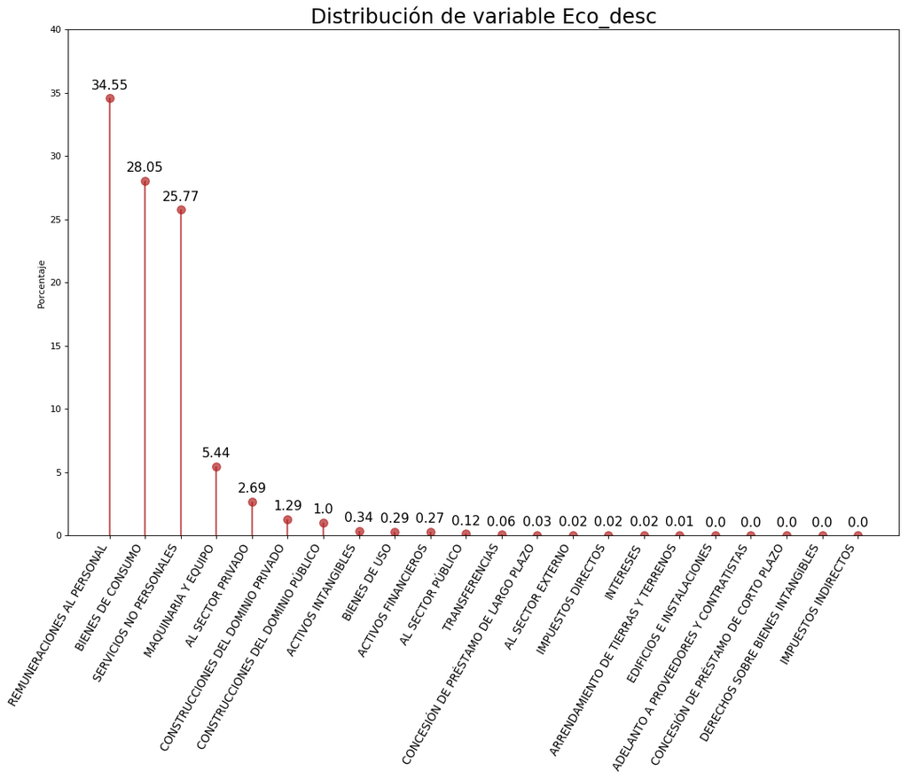

```python
df_datos = df_datos.rename(columns={'Eco_desc':'Etiquetas'}).head(22).reset_index()
fig, ax = plt.subplots(figsize=(16,10), dpi= 80)
ax.vlines(x=df_datos.index, ymin=0, ymax=df_datos.Porcentaje, color='firebrick', alpha=0.7, linewidth=2)
ax.scatter(x=df_datos.index, y=df_datos.Porcentaje, s=75, color='firebrick', alpha=0.7)
ax.set_title('Distribución de variable Eco_desc', fontdict={'size':22})
ax.set_ylabel('Porcentaje')
ax.set_xticks(df_datos.index)
ax.set_xticklabels(df_datos.Etiquetas.str.upper(), rotation=60, fontdict={'horizontalalignment': 'right', 'size':12})
ax.set_ylim(0, 40)
for row in df_datos.itertuples():
    ax.text(row.Index, row.Porcentaje+.5, s=round(row.Porcentaje, 2), horizontalalignment= 'center', verticalalignment='bottom', fontsize=14)

plt.show()
```

Análisis sobre la variable Fte_desc

```python
df_datos = df_categoricas[["Fte_desc"]].groupby(["Fte_desc"])["Fte_desc"].count().reset_index(name='Cantidad')
df_datos["Porcentaje"] = df_datos["Cantidad"]/df_datos["Cantidad"].sum() * 100
df_datos = df_datos.sort_values(by="Cantidad", ascending = False)
display(df_datos)
```

|  | Fte_desc | Cantidad | Porcentaje |
| --- | --- | --- | --- |
| 4 | Tesoro De La Ciudad | 42906 | 87.920 |
| 3 | Recursos Propios | 2235 | 4.580 |
| 5 | Transferencias Afectadas | 2015 | 4.129 |
| 2 | Recursos Con Afectacion Especifica | 1086 | 2.225 |
| 6 | Transferencias Internas | 525 | 1.076 |
| 0 | Financiamiento Externo | 31 | 0.064 |
| 1 | Financiamiento Interno | 3 | 0.006 |

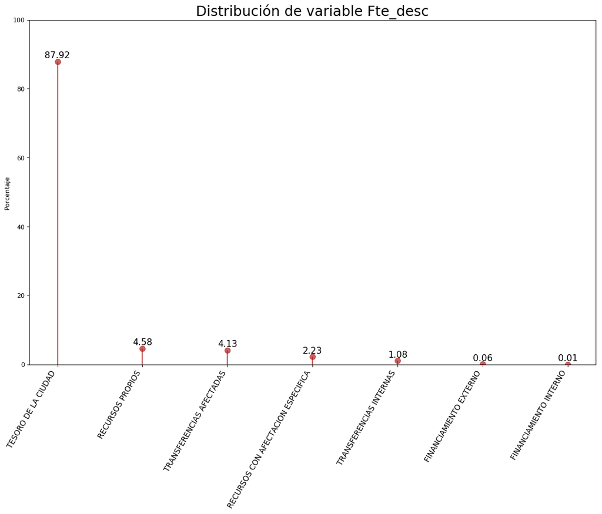

```python
df_datos = df_datos.rename(columns={'Fte_desc':'Etiquetas'}).head(20).reset_index()
fig, ax = plt.subplots(figsize=(16,10), dpi= 80)
ax.vlines(x=df_datos.index, ymin=0, ymax=df_datos.Porcentaje, color='firebrick', alpha=0.7, linewidth=2)
ax.scatter(x=df_datos.index, y=df_datos.Porcentaje, s=75, color='firebrick', alpha=0.7)
ax.set_title('Distribución de variable Fte_desc', fontdict={'size':22})
ax.set_ylabel('Porcentaje')
ax.set_xticks(df_datos.index)
ax.set_xticklabels(df_datos.Etiquetas.str.upper(), rotation=60, fontdict={'horizontalalignment': 'right', 'size':12})
ax.set_ylim(0, 100)
for row in df_datos.itertuples():
    ax.text(row.Index, row.Porcentaje+.5, s=round(row.Porcentaje, 2), horizontalalignment= 'center', verticalalignment='bottom', fontsize=14)

plt.show()
```

Análisis sobre la variable Geo_desc

```python
df_datos = df_categoricas[["Geo_desc"]].groupby(["Geo_desc"])["Geo_desc"].count().reset_index(name='Cantidad')
df_datos["Porcentaje"] = df_datos["Cantidad"]/df_datos["Cantidad"].sum() * 100
df_datos = df_datos.sort_values(by="Cantidad", ascending = False)
display(df_datos)
```

|  | Geo_desc | Cantidad | Porcentaje |
| --- | --- | --- | --- |
| 0 | Comuna 1 | 18187 | 37.268 |
| 9 | Comuna 4 | 13550 | 27.766 |
| 8 | Comuna 3 | 2129 | 4.363 |
| 13 | Comuna 8 | 1791 | 3.670 |
| 6 | Comuna 15 | 1673 | 3.428 |
| 5 | Comuna 14 | 1523 | 3.121 |
| 12 | Comuna 7 | 1508 | 3.090 |
| 14 | Comuna 9 | 1354 | 2.775 |
| 11 | Comuna 6 | 1187 | 2.432 |
| 7 | Comuna 2 | 1128 | 2.311 |
| 4 | Comuna 13 | 1008 | 2.066 |
| 10 | Comuna 5 | 995 | 2.039 |
| 3 | Comuna 12 | 975 | 1.998 |
| 2 | Comuna 11 | 970 | 1.988 |
| 1 | Comuna 10 | 746 | 1.529 |
| 15 | Zona Externa A La Ciudad | 77 | 0.158 |

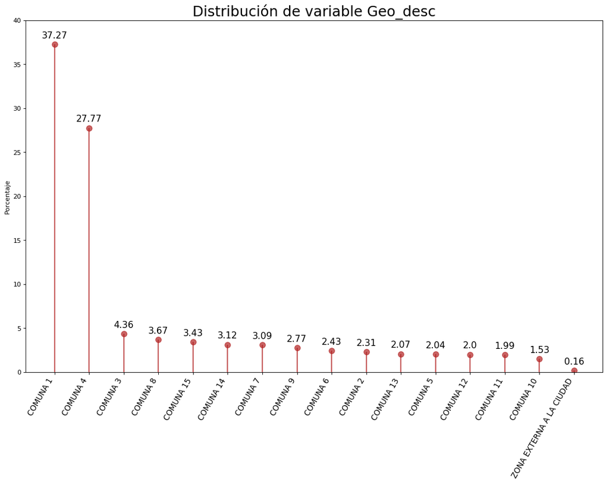

```python
df_datos = df_datos.rename(columns={'Geo_desc':'Etiquetas'}).head(20).reset_index()
fig, ax = plt.subplots(figsize=(16,10), dpi= 80)
ax.vlines(x=df_datos.index, ymin=0, ymax=df_datos.Porcentaje, color='firebrick', alpha=0.7, linewidth=2)
ax.scatter(x=df_datos.index, y=df_datos.Porcentaje, s=75, color='firebrick', alpha=0.7)
ax.set_title('Distribución de variable Geo_desc', fontdict={'size':22})
ax.set_ylabel('Porcentaje')
ax.set_xticks(df_datos.index)
ax.set_xticklabels(df_datos.Etiquetas.str.upper(), rotation=60, fontdict={'horizontalalignment': 'right', 'size':12})
ax.set_ylim(0, 40)
for row in df_datos.itertuples():
    ax.text(row.Index, row.Porcentaje+.5, s=round(row.Porcentaje, 2), horizontalalignment= 'center', verticalalignment='bottom', fontsize=14)

plt.show()
```

Análisis sobre las variables numéricas.

Para este análisis excluimos las columnas que representan códigos y solo tomamos las que representan algun valor de intereés. Aprovechando las bondades de la función describre presentamos los resultados de las 4 variables de interes en una tabla.

```python
df_numericas = presupuesto[["Sanción","Vigente","Definitivo","Devengado"]]
```

```python
pd.options.display.float_format = "{:.3f}".format
df_numericas.describe()
```

|  | Sanción | Vigente | Definitivo | Devengado |
| --- | --- | --- | --- | --- |
| count | 48801.000 | 48801.000 | 48801.000 | 48801.000 |
| mean | 4565606.605 | 4660883.413 | 2406347.497 | 2081568.955 |
| std | 43003433.605 | 54857115.918 | 46065419.979 | 45597285.779 |
| min | 0.000 | 0.000 | 0.000 | 0.000 |
| 25% | 0.000 | 7600.000 | 0.000 | 0.000 |
| 50% | 41000.000 | 84816.000 | 9170.000 | 6179.340 |
| 75% | 550000.000 | 845000.000 | 273456.400 | 222314.360 |
| max | 4008702080.000 | 7952610958.000 | 7952610957.700 | 7952610957.700 |

Graficos

Para lograr una mejor visualización en los boxplot los outlier fueron ya que rompia la escala del grafico

Variable Sanción

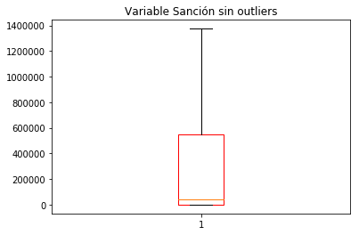

```python
plt.boxplot(df_numericas['Sanción'], boxprops=dict(color='red'), showfliers=False)
plt.title('Variable Sanción sin outliers');
```

Variable Vigente

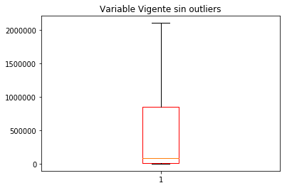

```python
plt.boxplot(df_numericas['Vigente'], boxprops=dict(color='red'), showfliers=False)
plt.title('Variable Vigente sin outliers');
```

Variable Definitivo

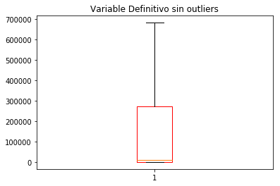

```python
plt.boxplot(df_numericas['Definitivo'], boxprops=dict(color='red'), showfliers=False)
plt.title('Variable Definitivo sin outliers');
```

Variable Devengado

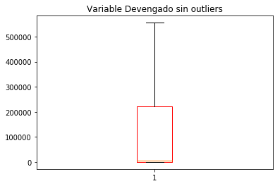

```python
plt.boxplot(df_numericas['Devengado'], boxprops=dict(color='red'), showfliers=False)
plt.title('Variable Devengado sin outliers');
```